# R Notebook

## **Kids Hobby Prediction Dataset**

**1.Problem**

Children often find themselves at a crossroads when it comes to discovering their passions or hobbies, be it in academics, arts, or sports. Recognizing the importance of guiding children towards activities they are passionate about; we have curated a dataset obtained through surveys conducted with parents. This dataset compiles valuable information about children’s preferences, enabling the creation of a classification model aimed at predicting kids’ hobbies.

In this exploratory journey, we delve into the dataset to uncover patterns and insights that can assist parents in understanding their child’s inclinations better. Through the application of clustering techniques, we aim to categorize children based on number of columns (Fav_sub , Scholarship, etc..). The ultimate goal is to provide parents with meaningful recommendations, fostering an environment where children can thrive in activities that genuinely resonate with their interests.

By analyzing this dataset, we hope to offer insightful information that will aid parents in guiding their kids toward the right hobbies.

**-------------------------------------------------------------------------------------------------------------------**

**2.Data Mining Task**

The data mining task at hand revolves around predicting kids’ hobbies based on a dataset named “Hobby_Data,” obtained through specific questions posed to their parents regarding preferences, capabilities, and achievements. This dataset serves as the foundation for two primary data mining tasks: classification and clustering. In the classification process, the goal is to train a machine learning model to be capable of accurately predicting a child’s hobby as either “academic,” “art,” or “sports.” This requires using the data collected from parents to establish patterns and relationships that guide the model in making accurate predictions. Concurrently, the clustering process involves partitioning the dataset into meaningful clusters, grouping together children with similar characteristics or preferences. Through these dual approaches, the data mining task aims to develop a robust predictive model capable of accurately categorizing children’s hobbies in order to uncover the inherent structures, patterns, and associations within the dataset, contributing to a deeper understanding of the diverse interests and engagement levels of the young population in academic, artistic, and sports-related activities.

**-------------------------------------------------------------------------------------------------------------------**

**3.Data**

Following the selection of our data set (“Hobby_Data”) which predicts kids’ hobbies, that was collected by asking their parents specific questions about their kid’s preferences, capabilities, and achievements. To help us train the machine to predict the kid’s hobby. We will begin to preprocess and analyze the data.

The source: https://www.kaggle.com/datasets/abtabm/hobby-prediction-basic Number of objects: 1601 Number of attributes: 14

**Attribute**

| **Attribute name** | **Description** | **Data type** |
| --- | --- | --- |
| Olympiad_Participation | Has your child participated in any Science/Maths | Boolean |
| Scholarship | Has he/she received any scholarship? | Boolean |
| School | Love’s going to school? | Boolean |
| Fav_sub | What is his/her favorite subject? | Categorical |
| Projects | Has done any projects under academics before? | Boolean |
| Grasp_pow | His/Her Grasping power (1-6) | Ordinal |
| Time_sprt | How much time does he/she spend playing outdoor/indoor games? | Ordinal |
| Medals | Medals won in Sports? | Boolean |
| Career_sprt | Want’s to pursue his/her career in sports? | Boolean |
| Act_sprt | Regular in his/her sports activities? | Boolean |
| Fant_arts | Love creating fantasy paintings? | Boolean |
| Won_arts | Won art competitions? | Ordinal |
| Time_art | Time utilized in Arts? | Ordinal |
| Predicted Hobby | predictions for the hobby that the kid wouldl ike | Categorical |

**General information about the data set:**

```r
str(Hobby_Data)
```

```
tibble [1,601 × 14] (S3: tbl_df/tbl/data.frame)
 $ Olympiad_Participation: chr [1:1601] "Yes" "Yes" "Yes" "Yes" ...
 $ Scholarship           : chr [1:1601] "Yes" "Yes" "Yes" "Yes" ...
 $ School                : chr [1:1601] "Yes" "Yes" "Yes" "Yes" ...
 $ Fav_sub               : chr [1:1601] "Mathematics" "Mathematics" "Science" "Mathematics" ...
 $ Projects              : chr [1:1601] "Yes" "Yes" "Yes" "Yes" ...
 $ Grasp_pow             : num [1:1601] 5 3 5 5 5 6 3 5 3 5 ...
 $ Time_sprt             : num [1:1601] 1 2 1 1 3 2 5 2 2 3 ...
 $ Medals                : chr [1:1601] "Yes" "No" "Yes" "Yes" ...
 $ Career_sprt           : chr [1:1601] "No" "No" "No" "No" ...
 $ Act_sprt              : chr [1:1601] "No" "No" "No" "No" ...
 $ Fant_arts             : chr [1:1601] "No" "No" "No" "No" ...
 $ Won_arts              : chr [1:1601] "Maybe" "No" "No" "Maybe" ...
 $ Time_art              : num [1:1601] 3 1 1 3 2 4 2 3 1 1 ...
 $ Predicted Hobby       : chr [1:1601] "Academics" "Academics" "Academics" "Academics" ...
```

**samples of raw dataset:**

```r
sample(Hobby_Data)
```

| Act_sprt | School | Won_arts | Time_sprt | Scholarship | Grasp_pow | Medals | Time_art | Career_sprt | Fant_arts | Predicted Hobby | Projects | Fav_sub | Olympiad_Participation |
| --- | --- | --- | --- | --- | --- | --- | --- | --- | --- | --- | --- | --- | --- |
| No | Yes | Maybe | 1 | Yes | 5 | Yes | 3 | No | No | Academics | Yes | Mathematics | Yes |
| No | Yes | No | 2 | Yes | 3 | No | 1 | No | No | Academics | Yes | Mathematics | Yes |
| No | Yes | No | 1 | Yes | 5 | Yes | 1 | No | No | Academics | Yes | Science | Yes |
| No | Yes | Maybe | 1 | Yes | 5 | Yes | 3 | No | No | Academics | Yes | Mathematics | Yes |
| No | Yes | No | 3 | Yes | 5 | No | 2 | No | No | Academics | Yes | Science | Yes |
| No | Yes | No | 2 | Yes | 6 | Yes | 4 | No | No | Academics | Yes | Mathematics | Yes |
| No | Yes | No | 5 | Yes | 3 | No | 2 | No | No | Academics | Yes | Science | Yes |
| No | Yes | Maybe | 2 | Yes | 5 | No | 3 | No | No | Academics | No | Mathematics | Yes |
| No | Yes | No | 2 | Yes | 3 | Yes | 1 | No | No | Academics | Yes | Science | Yes |
| No | Yes | No | 3 | Yes | 5 | Yes | 1 | No | No | Academics | Yes | Science | Yes |

[output cut: 990 more lines]

**variables distribution:**

```
In our dataset, numeric variables are not available; instead, we have three ordinal variables. Due to the nature of our data types, certain types of graphs, such as scatter plots and box plots, were not suitable for our analysis.
```

```r
install.packages("magrittr") # install only one time then put this command as comment after installation
```

```
Error in install.packages : Updating loaded packages
```

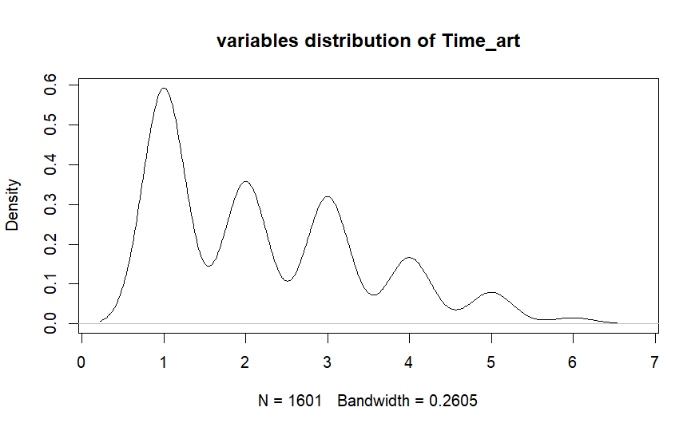

```r
library(magrittr) ## for pipe operations
Hobby_Data$Time_art %>% density() %>% plot(main='variables distribution of Time_art')
```

In the “Time_art” variable, parents were requested to assess the time their child dedicated to artistic pursuits like painting or paper crafting, using a scale ranging from 1 to 6, where 6 represents the highest level of involvement. It’s worth noting that the concentration of lower ratings at the lower end of the scale (1) is quite pronounced, and this tendency may be attributed to the inherent inclination of children towards physical activities.

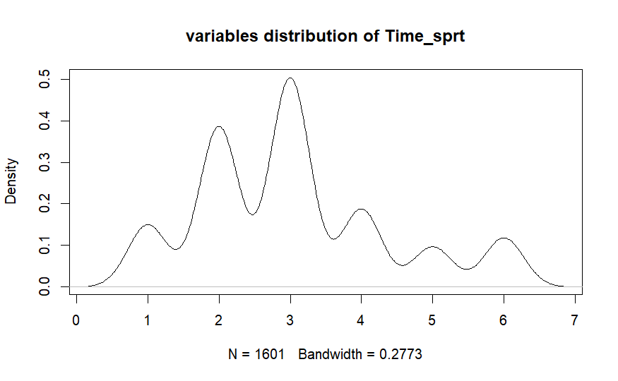

```r
Hobby_Data$Time_sprt %>% density() %>% plot(main='variables distribution of Time_sprt')
```

Parents were requested to assess their children’s involvement in sports on a scale from 1 to 6 within the “Time_sprt” variable. Notably, the most prevalent ranking was 3, suggesting a moderate level of sports participation. It’s interesting to observe that the distribution exhibits a shape akin to a bell curve, indicating that a substantial proportion of children have a genuine love for sports.

variables distribution of Grasp_pow:

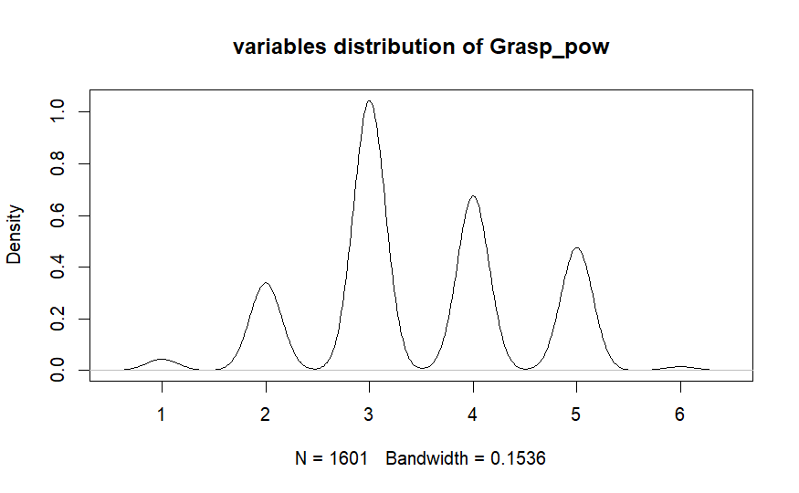

```r
Hobby_Data$Grasp_pow %>% density() %>% plot(main='variables distribution of Grasp_pow')
```

The density graph depicting parents’ ratings of their children’s grasp power, which ranges from 1 to 6, illustrates a trend where the most common rating is level 3, followed by level 4, level 5, level 2, level 1, and level 6. This distribution indicates that a substantial proportion of parents believe their children possess grasp power that is average or slightly above average (levels 3 and 4), with fewer children rated at the extremes (levels 1, 2, 5, and 6).

variables distribution of the class label ‘Predicted Hobby’:

```r
install.packages("dplyr") # install only one time then put this command as comment after installation
```

```
Error in install.packages : Updating loaded packages
```

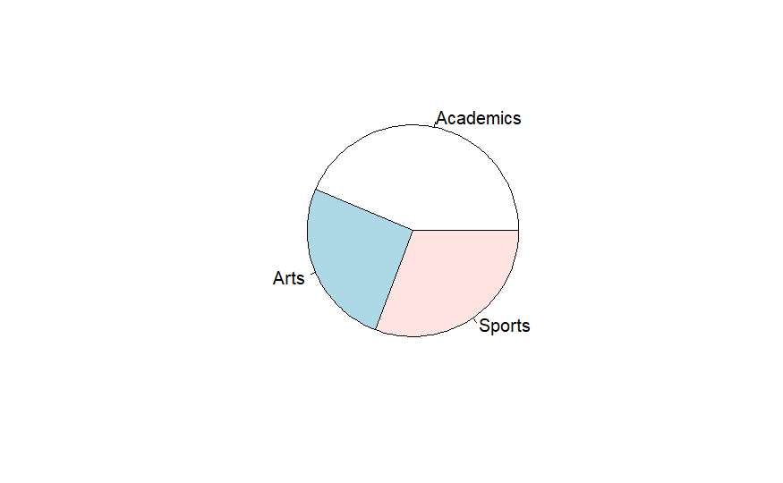

```r
library(dplyr)

dataset2 <- Hobby_Data %>% sample_n(1600)
table(dataset2$`Predicted Hobby`) %>% pie()
```

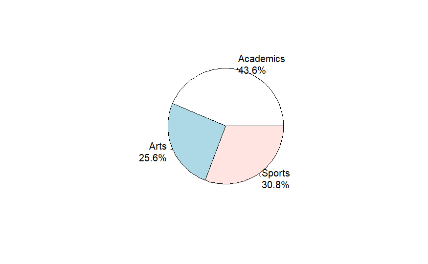

```r
tab <- dataset2$`Predicted Hobby` %>% table()
precentages <- tab %>% prop.table() %>% round(3) * 100
txt <- paste0(names(tab), '\n', precentages, '%')
pie(tab, labels=txt)
```

**Statistical measures :**

```r
find_mode <- function(x) {
  u <- unique(x)
  tab <- tabulate(match(x, u))
  u[tab == max(tab)]
}

find_mode(Hobby_Data$Time_art)
```

```
[1] 1
```

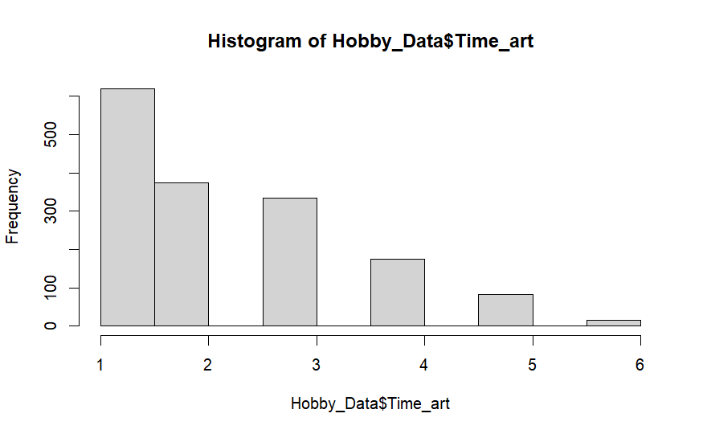

```r
# Updated upstream
hist(Hobby_Data$Time_art)
```

```r
#Stashed changes
```

The histogram makes it evident that the mode is equal to 1, and we believe that the high frequency of parents ranking “1” as the most chosen rank in the “Time_art” variable could be attributed to several factors. It might indicate that a significant number of parents perceive their children’s involvement in art activities as relatively low, possibly due to time constraints, academic priorities, or a limited interest in art. Alternatively, it could reflect that parents value a more balanced approach to their children’s activities, with a variety of interests and responsibilities sharing their time. This trend could also result from a cultural or educational emphasis on other subjects and extracurricular activities that compete for a child’s time, potentially leading to a lower ranking for art-related activities.

```r
find_mode(Hobby_Data$Grasp_pow)
```

```
[1] 3
```

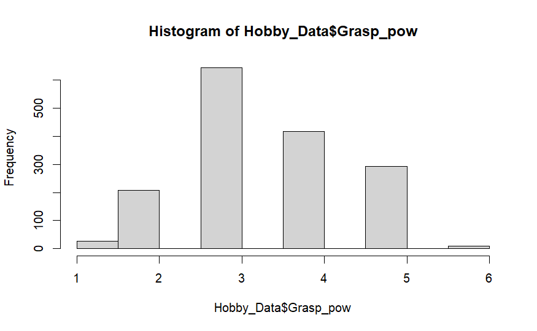

```r
hist(Hobby_Data$Grasp_pow)
```

Rank 3, in this context, may have been the most chosen rank because it likely represents an average or moderate level of grasp power. Parents may have assessed their children’s grasp power as neither exceptionally strong (rank 5 or 6) nor particularly weak (rank 1 or 2), resulting in the preference for the middle-ranking option. This choice could reflect a perception that their children’s grasp power falls within a typical or expected range, making it the most common rating.

```r
find_mode(Hobby_Data$Time_sprt)
```

```
[1] 3
```

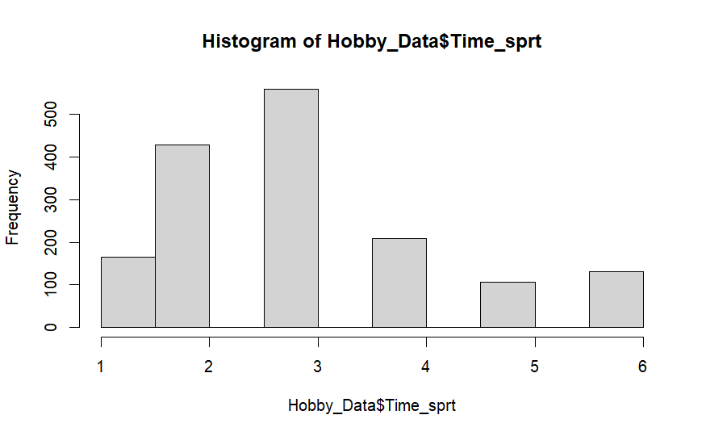

```r
hist(Hobby_Data$Time_sprt)
```

As shown in the histogram the rank 3 on a scale of 1 to 6 was likely the most chosen rank for assessing children’s involvement in sports because it represents a balanced middle ground. Parents may have perceived rank 3 as indicating that their children are moderately involved in sports, not excessively committed or disinterested. This middle-of-the-road ranking reflects a common perspective that many parents may hold, considering that extreme rankings, such as 1 or 6, might suggest either a lack of involvement or an excessive focus on sports, which may not align with their perception of their child’s overall well-rounded development.

The histogram graph for “Time_art” variable

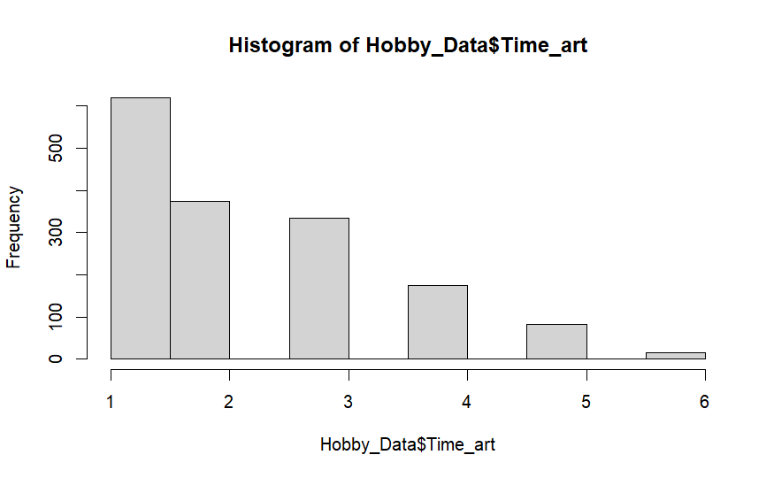

```r
hist(Hobby_Data$Time_art)
```

The histogram makes it evident that the mode is equal to 1, and we believe that the high frequency of parents ranking “1” as the most chosen rank in the “Time_art” variable could be attributed to several factors. It might indicate that a significant number of parents perceive their children’s involvement in art activities as relatively low, possibly due to time constraints, academic priorities, or a limited interest in art. Alternatively, it could reflect that parents value a more balanced approach to their children’s activities, with a variety of interests and responsibilities sharing their time. This trend could also result from a cultural or educational emphasis on other subjects and extracurricular activities that compete for a child’s time, potentially leading to a lower ranking for art-related activities.

```r
find_mode(Hobby_Data$Grasp_pow)
```

```
[1] 3
```

The histogram graph for “Grasp_pow” variable

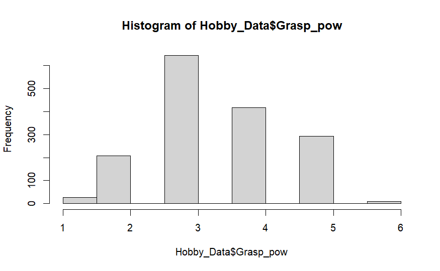

```r
hist(Hobby_Data$Grasp_pow)
```

Rank 3, in this context, may have been the most chosen rank because it likely represents an average or moderate level of grasp power. Parents may have assessed their children’s grasp power as neither exceptionally strong (rank 5 or 6) nor particularly weak (rank 1 or 2), resulting in the preference for the middle-ranking option. This choice could reflect a perception that their children’s grasp power falls within a typical or expected range, making it the most common rating.

```r
find_mode(Hobby_Data$Time_sprt)
```

```
[1] 3
```

The histogram graph for “Time_sprt” variable

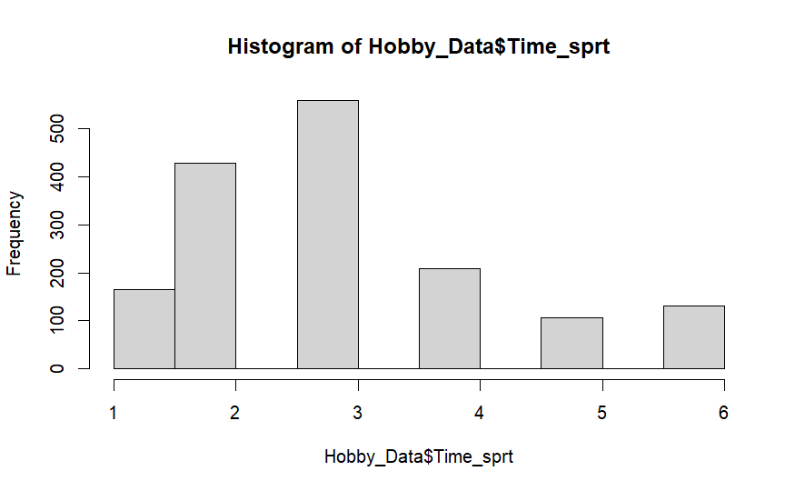

```r
hist(Hobby_Data$Time_sprt)
```

As shown in the histogram the rank 3 on a scale of 1 to 6 was likely the most chosen rank for assessing children’s involvement in sports because it represents a balanced middle ground. Parents may have perceived rank 3 as indicating that their children are moderately involved in sports, not excessively committed or disinterested. This middle-of-the-road ranking reflects a common perspective that many parents may hold, considering that extreme rankings, such as 1 or 6, might suggest either a lack of involvement or an excessive focus on sports, which may not align with their perception of their child’s overall well-rounded development.

**-------------------------------------------------------------------------------------------------------------------**

**5.Data preprocessing**

**#1#Data cleaning:**

During the data cleaning stage, finding and fixing faults, inconsistencies, and errors in a dataset helps it be more reliable and of higher quality for analysis and modeling. There are methods for handling missing values, detecting outliers, resolving inconsistencies, and standardizing formats.

view Dataset”Hobby_Data”

```r
View(Hobby_Data)
```

check missing value :

```r
is.na(Hobby_Data)
```

```
        Olympiad_Participation Scholarship School Fav_sub Projects Grasp_pow Time_sprt Medals Career_sprt Act_sprt Fant_arts Won_arts
   [1,]                  FALSE       FALSE  FALSE   FALSE    FALSE     FALSE     FALSE  FALSE       FALSE    FALSE     FALSE    FALSE
   [2,]                  FALSE       FALSE  FALSE   FALSE    FALSE     FALSE     FALSE  FALSE       FALSE    FALSE     FALSE    FALSE
   [3,]                  FALSE       FALSE  FALSE   FALSE    FALSE     FALSE     FALSE  FALSE       FALSE    FALSE     FALSE    FALSE
   [4,]                  FALSE       FALSE  FALSE   FALSE    FALSE     FALSE     FALSE  FALSE       FALSE    FALSE     FALSE    FALSE
   [5,]                  FALSE       FALSE  FALSE   FALSE    FALSE     FALSE     FALSE  FALSE       FALSE    FALSE     FALSE    FALSE
   [6,]                  FALSE       FALSE  FALSE   FALSE    FALSE     FALSE     FALSE  FALSE       FALSE    FALSE     FALSE    FALSE
   [7,]                  FALSE       FALSE  FALSE   FALSE    FALSE     FALSE     FALSE  FALSE       FALSE    FALSE     FALSE    FALSE
   [8,]                  FALSE       FALSE  FALSE   FALSE    FALSE     FALSE     FALSE  FALSE       FALSE    FALSE     FALSE    FALSE
   [9,]                  FALSE       FALSE  FALSE   FALSE    FALSE     FALSE     FALSE  FALSE       FALSE    FALSE     FALSE    FALSE
  [10,]                  FALSE       FALSE  FALSE   FALSE    FALSE     FALSE     FALSE  FALSE       FALSE    FALSE     FALSE    FALSE
  [11,]                  FALSE       FALSE  FALSE   FALSE    FALSE     FALSE     FALSE  FALSE       FALSE    FALSE     FALSE    FALSE
  [12,]                  FALSE       FALSE  FALSE   FALSE    FALSE     FALSE     FALSE  FALSE       FALSE    FALSE     FALSE    FALSE
  [13,]                  FALSE       FALSE  FALSE   FALSE    FALSE     FALSE     FALSE  FALSE       FALSE    FALSE     FALSE    FALSE
  [14,]                  FALSE       FALSE  FALSE   FALSE    FALSE     FALSE     FALSE  FALSE       FALSE    FALSE     FALSE    FALSE
```

[output cut: 130 more lines]

find the total null values in the dataset:

```r
sum(is.na(Hobby_Data))
```

```
[1] 0
```

This stage involves checking and deleting for null and missing values because they might have a significant impact on the data and cause errors and negative effects in subsequent steps.We simply looked for missing values, and there are not missing values in our dataset. According to our investigation, the dataset does not contain any outliers since it doesn’t have a numerical data type. Additionally, there are no inconsistent values or other errors.

Dataset after cleaning step:

```r
sample(Hobby_Data)
```

| Fant_arts | Time_sprt | Projects | Grasp_pow | Medals | Scholarship | Won_arts | Time_art | Fav_sub | Olympiad_Participation | School | Act_sprt | Predicted Hobby | Career_sprt |
| --- | --- | --- | --- | --- | --- | --- | --- | --- | --- | --- | --- | --- | --- |
| No | 1 | Yes | 5 | Yes | Yes | Maybe | 3 | Mathematics | Yes | Yes | No | Academics | No |
| No | 2 | Yes | 3 | No | Yes | No | 1 | Mathematics | Yes | Yes | No | Academics | No |
| No | 1 | Yes | 5 | Yes | Yes | No | 1 | Science | Yes | Yes | No | Academics | No |
| No | 1 | Yes | 5 | Yes | Yes | Maybe | 3 | Mathematics | Yes | Yes | No | Academics | No |
| No | 3 | Yes | 5 | No | Yes | No | 2 | Science | Yes | Yes | No | Academics | No |
| No | 2 | Yes | 6 | Yes | Yes | No | 4 | Mathematics | Yes | Yes | No | Academics | No |
| No | 5 | Yes | 3 | No | Yes | No | 2 | Science | Yes | Yes | No | Academics | No |
| No | 2 | No | 5 | No | Yes | Maybe | 3 | Mathematics | Yes | Yes | No | Academics | No |
| No | 2 | Yes | 3 | Yes | Yes | No | 1 | Science | Yes | Yes | No | Academics | No |
| No | 3 | Yes | 5 | Yes | Yes | No | 1 | Science | Yes | Yes | No | Academics | No |

[output cut: 990 more lines]

**#2#Second:Encoding:** This step includes a Converting categorical or non-numeric data into a numerical format, which is necessary for compatibility with subsequent steps in preprocessing.[1]

```r
Hobby_Data$Olympiad_Participation = factor(Hobby_Data$Olympiad_Participation,levels = c("No", "Yes"), labels = c(0, 1))
Hobby_Data$Scholarship = factor(Hobby_Data$Scholarship , levels = c("No", "Yes"), labels = c(0, 1))
Hobby_Data$School = factor(Hobby_Data$School, levels = c("No", "Yes"), labels = c(0, 1))
Hobby_Data$Projects = factor(Hobby_Data$Projects, levels = c("No", "Yes"), labels = c(0, 1))
Hobby_Data$Medals = factor(Hobby_Data$Medals, levels = c("No", "Yes"), labels = c(0, 1))
Hobby_Data$Career_sprt = factor(Hobby_Data$Career_sprt, levels = c("No", "Yes"), labels = c(0, 1))
Hobby_Data$Act_sprt = factor(Hobby_Data$Act_sprt, levels = c("No", "Yes"), labels = c(0, 1))
Hobby_Data$Fant_arts = factor(Hobby_Data$Fant_arts, levels = c("No", "Yes"), labels = c(0, 1))
Hobby_Data$Won_arts = factor(Hobby_Data$Won_arts, levels = c("No", "Maybe", "Yes"), labels = c(0, 2, 1))
Hobby_Data$Fav_sub = factor(Hobby_Data$Fav_sub, levels = c("Science", "Mathematics", "History/Geography", "Any language"), labels = c(1, 2, 3, 4))
Hobby_Data$`Predicted Hobby` <- factor(Hobby_Data$`Predicted Hobby`, levels = c("Academics", "Arts", "Sports"), labels = c(1, 2, 3))
```

Dataset after Encoding :

```r
sample(Hobby_Data)
```

| Fav_sub | Time_sprt | Projects | Scholarship | Grasp_pow | Predicted Hobby | Career_sprt | Time_art | Fant_arts | Olympiad_Participation | School | Won_arts | Act_sprt | Medals |
| --- | --- | --- | --- | --- | --- | --- | --- | --- | --- | --- | --- | --- | --- |
| 2 | 1 | 1 | 1 | 5 | 1 | 0 | 3 | 0 | 1 | 1 | 2 | 0 | 1 |
| 2 | 2 | 1 | 1 | 3 | 1 | 0 | 1 | 0 | 1 | 1 | 0 | 0 | 0 |
| 1 | 1 | 1 | 1 | 5 | 1 | 0 | 1 | 0 | 1 | 1 | 0 | 0 | 1 |
| 2 | 1 | 1 | 1 | 5 | 1 | 0 | 3 | 0 | 1 | 1 | 2 | 0 | 1 |
| 1 | 3 | 1 | 1 | 5 | 1 | 0 | 2 | 0 | 1 | 1 | 0 | 0 | 0 |
| 2 | 2 | 1 | 1 | 6 | 1 | 0 | 4 | 0 | 1 | 1 | 0 | 0 | 1 |
| 1 | 5 | 1 | 1 | 3 | 1 | 0 | 2 | 0 | 1 | 1 | 0 | 0 | 0 |
| 2 | 2 | 0 | 1 | 5 | 1 | 0 | 3 | 0 | 1 | 1 | 2 | 0 | 0 |
| 1 | 2 | 1 | 1 | 3 | 1 | 0 | 1 | 0 | 1 | 1 | 0 | 0 | 1 |
| 1 | 3 | 1 | 1 | 5 | 1 | 0 | 1 | 0 | 1 | 1 | 0 | 0 | 1 |

[output cut: 990 more lines]

**#3# Normalization and Discetization:**

We don’t need to use normalization and discetization in our dataset. Since our dataset doesn’t have numeric attributes and normalization involves mathematical operations, which can result in meaningless values and errors, Also, applying discretization leads to a loss of information and creates intervals and relationships that don’t exist between values.[2]

**#4#Feature Selection:**

To improve the accuracy of our predictions for the target class “Predicted Hobby” and decrease the processing time of our classifier, we will utilize feature selection techniques. These techniques enable us to eliminate redundant or irrelevant attributes from the dataset, resulting in a more concise subset of features that provide the most valuable information for our predictions.[3]

Specifically, we will use two feature selection methods: Rank Features by Importance and Feature Selection Using Recursive Feature Elimination (RFE).

1.**Rank Features by Importance:**

This method used in the code helps us determine which features are most important for predicting the “Predicted Hobby” class label in the dataset. It utilizes the Random Forest algorithm, known for its accurate prediction capabilities. This method calculates the importance of each feature by assessing its contribution to the overall accuracy of the predictions. By ranking the features based on their importance, we can identify the ones that have the greatest influence on determining hobbies.

Ensure the results are repeatable by setting a seed:

```r
set.seed(7)
```

Load the necessary libraries:

```r
install.packages("caret")
install.packages("randomForest")
library(caret)
library(randomForest)
```

Separate the predictors and the class label:

```r
predictors <- Hobby_Data[, -14]  # Excluding the class label (Predicted Hobby)
class_label <- Hobby_Data$`Predicted Hobby`
```

Train a Random Forest model:

```r
model <- randomForest(predictors, class_label, importance = TRUE)
```

Get the variable importance:

```r
importance <- importance(model)
```

Rank the features by importance:

```r
ranked_features <- sort(importance[, "MeanDecreaseGini"], decreasing = TRUE)
```

Print the ranked features:

```r
print(ranked_features)
```

```
           Career_sprt               Won_arts              Fant_arts Olympiad_Participation               Time_art
             242.82209              146.54945              109.53323              107.35680               90.25903
           Scholarship               Act_sprt              Grasp_pow              Time_sprt                 School
              70.96982               57.96251               42.28115               36.10260               24.51517
               Fav_sub                 Medals               Projects
              24.10421               16.33709               12.70597
```

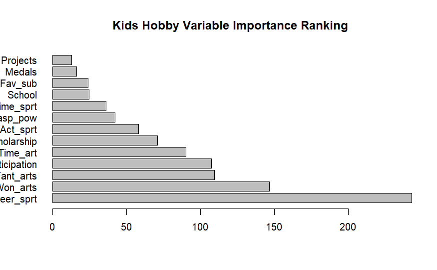

```r
barplot(ranked_features, horiz = TRUE, las = 1, main = "Kids Hobby Variable Importance Ranking")
```

2.**Feature Selection Using RFE:**

The Recursive Feature Elimination (RFE) method with Random Forest is a technique used to select the most important features for accurate predictions . It iteratively eliminates less relevant features, retraining the model at each step to evaluate performance. By focusing on the most informative features, RFE improves reduces complexity, and enhances prediction accuracy. It is particularly effective with Random Forest due to its ability to handle complex relationships and high-dimensional data. RFE helps identify the most important attributes associated with the target variable, enabling the creation of more efficient and accurate models.

Ensure the results are repeatable by setting a seed:

```r
set.seed(7)
```

Load the necessary libraries:

```r
library(caret)
```

Define the control parameters for RFE using random forest selection function:

```r
control <- rfeControl(functions = rfFuncs, method = "cv", number = 10)
```

Extract the predictor variables from Hobby_Data:

```r
predictors <- Hobby_Data[, -ncol(Hobby_Data)]
```

Convert the outcome variable to a factor:

```r
outcome <- as.factor(Hobby_Data$`Predicted Hobby`)
```

Run the RFE algorithm:

```r
results <- rfe(predictors, outcome, sizes = 1:ncol(Hobby_Data), rfeControl = control)
```

Summarize the results:

```r
print(results)
```

```
Recursive feature selection

Outer resampling method: Cross-Validated (10 fold)

Resampling performance over subset size:
```

|  | Variables | Accuracy | Kappa | AccuracySD | KappaSD | Selected |
| --- | --- | --- | --- | --- | --- | --- |
| 1 | 1 | 0.6996 | 0.5086 | 0.01698 | 0.02960 |  |
| 2 | 2 | 0.8488 | 0.7671 | 0.02773 | 0.04559 |  |
| 3 | 3 | 0.8763 | 0.8095 | 0.01483 | 0.02236 |  |
| 4 | 4 | 0.9019 | 0.8486 | 0.01918 | 0.02954 |  |
| 5 | 5 | 0.9094 | 0.8599 | 0.02386 | 0.03725 |  |
| 6 | 6 | 0.9119 | 0.8640 | 0.01825 | 0.02837 |  |
| 7 | 7 | 0.9213 | 0.8784 | 0.02069 | 0.03223 |  |
| 8 | 8 | 0.9238 | 0.8822 | 0.02336 | 0.03643 |  |
| 9 | 9 | 0.9250 | 0.8842 | 0.01845 | 0.02874 |  |
| 10 | 10 | 0.9288 | 0.8900 | 0.02049 | 0.03187 |  |

[output cut: 3 more lines]

```
The top 5 variables (out of 13):
   Career_sprt, Won_arts, Time_art, Fant_arts, Olympiad_Participation
```

List the chosen features selected by RFE:

```r
predictors(results)
```

```
 [1] "Career_sprt"            "Won_arts"               "Time_art"               "Fant_arts"              "Olympiad_Participation"
 [6] "Scholarship"            "Act_sprt"               "Grasp_pow"              "Time_sprt"              "School"
[11] "Medals"                 "Projects"               "Fav_sub"
```

Plot the results:

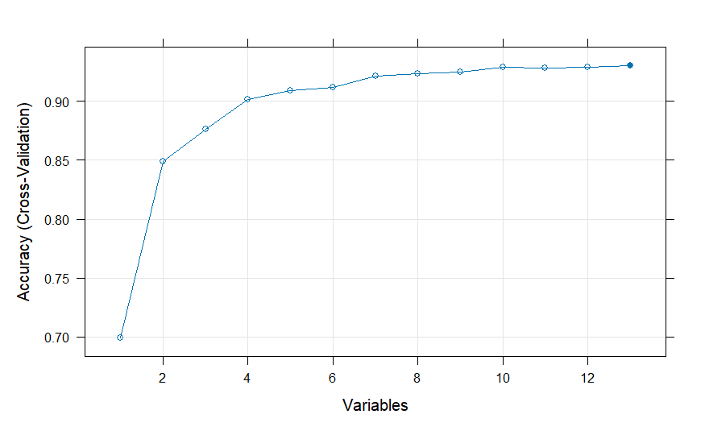

```r
plot(results, type = c("g", "o"))
```

3.**Removing Irrelevant Columns:**

Remove the specified columns from the Hobby_Kids dataset:

```r
Hobby_Data <- Hobby_Data[, !(colnames(Hobby_Data) %in% c("School", "Medals"))]
```

sample of our dataset after finishing from pre-processing:

```r
sample(Hobby_Data)
```

| Fant_arts | Scholarship | Act_sprt | Time_sprt | Career_sprt | Projects | Time_art | Won_arts | Grasp_pow | Predicted Hobby | Fav_sub | Olympiad_Participation |
| --- | --- | --- | --- | --- | --- | --- | --- | --- | --- | --- | --- |
| 0 | 1 | 0 | 1 | 0 | 1 | 3 | 2 | 5 | 1 | 2 | 1 |
| 0 | 1 | 0 | 2 | 0 | 1 | 1 | 0 | 3 | 1 | 2 | 1 |
| 0 | 1 | 0 | 1 | 0 | 1 | 1 | 0 | 5 | 1 | 1 | 1 |
| 0 | 1 | 0 | 1 | 0 | 1 | 3 | 2 | 5 | 1 | 2 | 1 |
| 0 | 1 | 0 | 3 | 0 | 1 | 2 | 0 | 5 | 1 | 1 | 1 |
| 0 | 1 | 0 | 2 | 0 | 1 | 4 | 0 | 6 | 1 | 2 | 1 |
| 0 | 1 | 0 | 5 | 0 | 1 | 2 | 0 | 3 | 1 | 1 | 1 |
| 0 | 1 | 0 | 2 | 0 | 0 | 3 | 2 | 5 | 1 | 2 | 1 |
| 0 | 1 | 0 | 2 | 0 | 1 | 1 | 0 | 3 | 1 | 1 | 1 |
| 0 | 1 | 0 | 3 | 0 | 1 | 1 | 0 | 5 | 1 | 1 | 1 |

[output cut: 990 more lines]

we can see that the two columns are deleted(“School”, “Medals”).

**Balanced Data**

```r
# Calculate class imbalance
class_imbalance <- max(prop.table(table(Hobby_Data$`Predicted Hobby`))) - min(prop.table(table(Hobby_Data$`Predicted Hobby`)))

# Print the result
print(class_imbalance)
```

```
[1] 0.1805122
```

**-------------------------------------------------------------------------------------------------------------------**

**5.Data Mining Technique**

**Classification Technique:**

In the realm of classification for data mining, the selection of attributes or features plays a pivotal role in building robust models. This process involves identifying the most informative attributes that aid in accurately predicting the target variable. Simultaneously, we choose three different split sizes: (“90%”, “10%”), (“80%”, “20%”), and (“70%”, “30%”). These varying sizes are selected to provide insight into the model’s performance with different amounts of data, which is vital for detecting unique patterns and confirming the model’s consistency in various situations.

1-Information Gain (IG): Information Gain serves as a criterion to determine the relevance of attributes by measuring the amount of information provided by each attribute. Higher Information Gain suggests attributes that are more influential in the classification process.

R Packages and Methods: R Package: rpart Method: Decision Tree (implemented via rpart package) Procedure: Using the rpart package in R, the decision tree model is built by partitioning the dataset based on the attribute with the highest Information Gain. The parms = list(split = “information”) parameter signifies the use of Information Gain for splitting.

2-Gini Index: Gini Index, employed in decision tree algorithms like CART, quantifies the probability of misclassifying a randomly chosen element based on the distribution of labels in a subset. It identifies attributes that minimize misclassification and contribute significantly to the classification process.

R Packages and Methods: R Package: rpart Method: Decision Tree (using rpart package) Procedure: Utilizing the rpart package, the decision tree model is constructed based on the Gini Index. The Gini Index helps determine attribute importance and guides the splitting of nodes in the tree for optimal classification.

3-Gain Ratio: The Gain Ratio is an enhancement of Information Gain that addresses the bias towards attributes with a larger number of values. It normalizes the Information Gain by considering the intrinsic information of each attribute.

R Packages and Methods: R Package: C50 Method: Decision Tree (via C50 package) Procedure: The C50 package in R facilitates the implementation of the Gain Ratio within a decision tree framework. By employing this package, the model accounts for attribute selection based on the Gain Ratio, ensuring a more balanced evaluation of attributes. In these techniques, the choice of methodology—Decision Trees based on different attribute selection measures—provides a versatile approach to classification. The selection of the most appropriate method often involves experimentation and comparative analysis to determine which attribute selection measure yields the most accurate and interpretable models for the given dataset.

Each method allows for a unique perspective on attribute importance, contributing to the overall accuracy and robustness of the classification model. Experimentation with these techniques helps in understanding the impact of attribute selection on model performance, providing valuable insights into feature importance and classification accuracy.

**Clustering Techniques:**

since the k-mean does not suitable to our data because the k-means algorithm is not applicable to categorical data, because it relies on the Euclidean distance metric tomeasure the similarity between data points.and other things we mention later,we decide to use k-medoids(PAM). Unlike k-means, k-medoids does not rely on the mean as a representative centroid but employs medoids, which are actual data points within the clusters, and the algorithm defines clusters based on partitioning around medoids. This feature makes k-medoids particularly suitable for categorical data.

since clustering apply with a data set without ground truth we remove it before we start to make clustering, first we convert type from factor columns to numeric then scaled all columns, then we make validation to determined how many clusters by using (Silhouette coefficient,Elbow method, average silhouette) method

second we apply PAM for 3 number of cluster with calculation of (BCubed recall, BCubed precision,wws, average silhouette width)

third after we apply PAM and some methods for every number of cluster, we compare the result and chose k=3 to be the best number of cluster based on our calculation and visuals.

Packages Used: ggplot2: Enables visually appealing and customizable plots, widely used for data visualization in R. magrittr: Facilitates writing readable code by employing the pipe operator (%>%) for data manipulation operations. dplyr: Offers tools for data manipulation and transformation, providing functions for filtering, selecting, and arranging data. factoextra: Useful for extracting and visualizing information from principal component analysis (PCA) and clustering results. cluster: Provides functions for clustering algorithms such as k-means. k-medoids, hierarchical clustering .

**-------------------------------------------------------------------------------------------------------------------**

**6.Implement Classification and clustering**

**#1#Classification**

After preprocessing, we will proceed to the classification step. In this phase, as part of supervised learning, we will apply a classification algorithm to assign each data point into predefined categories based on its attributes. This involves selecting the most relevant features that have been cleaned and formatted during preprocessing. The selected model will then learn from training data, enabling it to predict the category of new, unseen data accurately. This step is essential for making informed decisions or predictions based on the data.

We implement a decision tree on the dataset, which has been partitioned into Training and Test sets using the percentage split method. This method ensures that each subset is a randomized, representative sample of the entire dataset, thus minimizing bias and enabling consistent model performance evaluation. We choose three different split sizes: (“90%”, “10%”), (“80%”, “20%”), and (“70%”, “30%”). These varying sizes are selected to provide insight into the model’s performance with different amounts of data, which is vital for detecting unique patterns and confirming the model’s consistency in various situations.

In the final steps, we utilize data visualization tools to create visual representations of our decision trees. Additionally, we conduct an exhaustive evaluation of the model, employing a “Confusion Matrix” to illustrate the outcomes clearly.

**Information Gain**

Information Gain is particularly useful when dealing with categorical target variables using Information Gain for the initial partitioning of a dataset when building a decision tree It’s based on the concept of entropy and aims to maximize the homogeneity of subsets after each split. This approach helps create an effective decision tree by selecting features that provide the most information for predicting the target variable.[4]

**1-Information Gain(70%,30%)**

```r
# Load the required packages
library(rpart)
library(rpart.plot)
library(caret)

# Set the seed for reproducibility
set.seed(1234)

# Split the data into training and testing sets
ind <- sample(2, nrow(Hobby_Data), replace=TRUE, prob=c(0.7, 0.3))
trainData <- Hobby_Data[ind == 1,]
testData <- Hobby_Data[ind == 2,]

# Define the formula for the decision tree
myFormula <- `Predicted Hobby` ~ Scholarship + Fav_sub + Projects + Grasp_pow + Time_sprt + Career_sprt + Act_sprt + Fant_arts + Won_arts + Time_art + Olympiad_Participation

# Create the decision tree model with the "information" splitting criterion
Hobby_Data_ctree <- rpart(myFormula, data = trainData, method = "class", parms = list(split = "information"))





# Print the decision tree
print(Hobby_Data_ctree)
```

```
n= 1142

node), split, n, loss, yval, (yprob)
      * denotes terminal node

 1) root 1142 657 1 (0.42469352 0.25919440 0.31611208)
   2) Career_sprt=0 707 255 1 (0.63932107 0.33946252 0.02121641)
     4) Won_arts=0,2 476  52 1 (0.89075630 0.07773109 0.03151261) *
     5) Won_arts=1 231  28 2 (0.12121212 0.87878788 0.00000000)
      10) Fant_arts=0 26   7 1 (0.73076923 0.26923077 0.00000000) *
      11) Fant_arts=1 205   9 2 (0.04390244 0.95609756 0.00000000) *
   3) Career_sprt=1 435  89 3 (0.07586207 0.12873563 0.79540230)
     6) Fant_arts=1 107  55 2 (0.17757009 0.48598131 0.33644860)
      12) Time_art>=2.5 56   7 2 (0.07142857 0.87500000 0.05357143) *
      13) Time_art< 2.5 51  18 3 (0.29411765 0.05882353 0.64705882) *
     7) Fant_arts=0 328  18 3 (0.04268293 0.01219512 0.94512195) *
```

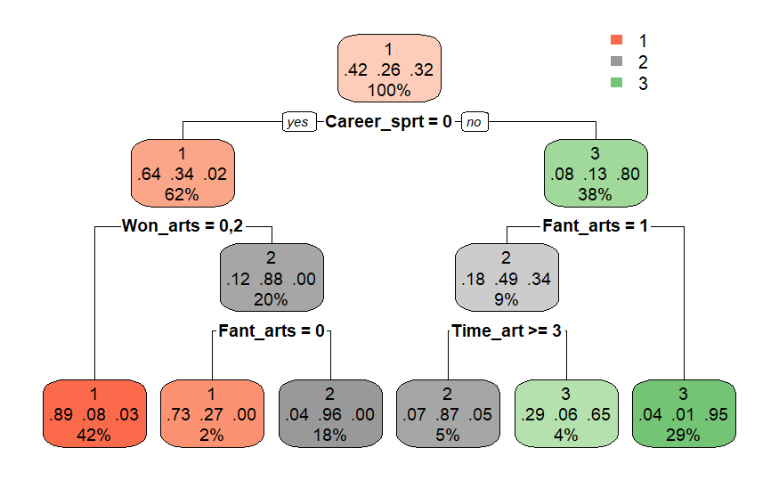

```r
# Plot the decision tree

rpart.plot(Hobby_Data_ctree)
```

```r
NA
NA
NA
NA
```

**Decision Tree Analysis Using Information gain(70/30):**

In Frist Tree ,we devide dataset into training set and test set with size(%70,%30) respectively. As you can see in the figure, the root node (“Career_sprt”) serves as the starting point for the classification process since have the heights Gain. The dataset has a distribution of approximately 42.47% for class 1(“Academics”), 25.92% for class 2(“Arts”), and 31.61% for class 3 (“Sports”).

The tree further branches based on the values of the “Career_sprt” if equal 0, tree branches based on”Won_arts” ,and majority of instances fall into “Acadimcs”, constituting 63.93% , if”Won_arts” equal 0 or2 In this case the tree terminates with a leaf node indicating a high probability 89.08% for “Acadimcs”.else the instances are classified based on “Fant_arts” into “Arts” with a probability 88%,if equal 0 the instances are classified into “Academics” with a probability of 73% ,else the instances are classified into “Arts” with a high probability 96%, if “Career_sprt” is 1, the tree further branches based on the “Fant_arts” into “Sports” with a probability 80%. If “Fant_arts” is 1 , there is another split based on the “Time_art” feature into “Arts” with a probability 49%. If “Time_art” is greater than or equal to 3, the instances are classified into “Arts” with a probability of 87% . On the other hand, if “Time_art” is less than 3, the instances are classified into “Sports” with a probability of 65% .If “Fant_arts” not equal 1 , the instances are classified into “Sports” with a high probability 95%, as indicated by the leaf node.

**First Confusion matrix**

```r
# Predict on the test data
testPred <- predict(Hobby_Data_ctree, newdata = testData, type = 'class')

# Check the accuracy of the model
accuracy <- sum(testPred == testData$`Predicted Hobby`) / nrow(testData) * 100
cat('Accuracy:', accuracy, '\n')
```

```
Accuracy: 89.32462
```

```r
# Create a confusion matrix
conf_matrix <- table(Actual = testData$`Predicted Hobby`, Predicted = testPred)

# Calculate precision for each class
precision_class_1 <- conf_matrix[1, 1] / sum(conf_matrix[1, ])
precision_class_2 <- conf_matrix[2, 2] / sum(conf_matrix[2, ])
precision_class_3 <- conf_matrix[3, 3] / sum(conf_matrix[3, ])

# Calculate sensitivity for each class
sensitivity_class_1 <- conf_matrix[1, 1] / sum(conf_matrix[1, ])
sensitivity_class_2 <- conf_matrix[2, 2] / sum(conf_matrix[2, ])
sensitivity_class_3 <- conf_matrix[3, 3] / sum(conf_matrix[3, ])

# Calculate specificity for each class
specificity_class_1 <- sum(diag(conf_matrix[-1, -1])) / sum(conf_matrix[-1, ])
specificity_class_2 <- sum(conf_matrix[c(1, 3), c(1, 3)]) / sum(conf_matrix[c(1, 3), ])
specificity_class_3 <- sum(conf_matrix[c(1, 2), c(1, 2)]) / sum(conf_matrix[c(1, 2), ])

# Calculate macro-average sensitivity
macro_avg_sensitivity <- (sensitivity_class_1 + sensitivity_class_2 + sensitivity_class_3) / 3

# Calculate macro-average specificity
macro_avg_specificity <- (specificity_class_1 + specificity_class_2 + specificity_class_3) / 3

# Calculate macro-average precision
macro_avg_precision <- (precision_class_1 + precision_class_2 + precision_class_3) / 3

# Print macro-average sensitivity
cat('Average Sensitivity:', macro_avg_sensitivity, '\n')
```

```
Average Sensitivity: 0.8872391
```

```r
# Print macro-average specificity
cat('Average Specificity:', macro_avg_specificity, '\n')
```

```
Average Specificity: 0.9291466
```

```r
# Print macro-average precision
cat('Average Precision:', macro_avg_precision, '\n')
```

```
Average Precision: 0.8872391
```

```r
# Print precision for each class
cat('Precision for Class 1:', precision_class_1, ' \n')
```

```
Precision for Class 1: 0.911215
```

```r
cat('Precision for Class 2:', precision_class_2, '  \n')
```

```
Precision for Class 2: 0.8421053
```

```r
cat('Precision for Class 3:', precision_class_3, ' \n')
```

```
Precision for Class 3: 0.9083969
```

```r
# Print sensitivity for each class
cat('Sensitivity for Class 1:', sensitivity_class_1, '\n')
```

```
Sensitivity for Class 1: 0.911215
```

```r
cat('Sensitivity for Class 2:', sensitivity_class_2, '\n')
```

```
Sensitivity for Class 2: 0.8421053
```

```r
cat('Sensitivity for Class 3:', sensitivity_class_3, '\n')
```

```
Sensitivity for Class 3: 0.9083969
```

```r
# Print specificity for each class
cat('Specificity for Class 1:', specificity_class_1, '\n')
```

```
Specificity for Class 1: 0.877551
```

```r
cat('Specificity for Class 2:', specificity_class_2, '\n')
```

```
Specificity for Class 2: 0.973913
```

```r
cat('Specificity for Class 3:', specificity_class_3, '\n')
```

```
Specificity for Class 3: 0.9359756
```

**2-Information Gain(80%,20%)**

```r
library(rpart)

library(caTools)
library(rpart.plot)
library(caret)

# Set the seed for reproducibility
set.seed(1234)

# Split the data into training and testing sets
ind <- sample(2, nrow(Hobby_Data), replace=TRUE, prob=c(0.8, 0.2))
trainData <- Hobby_Data[ind == 1,]
testData <- Hobby_Data[ind == 2,]

# Define the formula for the decision tree
myFormula <- `Predicted Hobby` ~ Scholarship + Fav_sub + Projects + Grasp_pow + Time_sprt + Career_sprt + Act_sprt + Fant_arts + Won_arts + Time_art + Olympiad_Participation

# Create the decision tree model with the "information" splitting criterion
Hobby_Data_ctree <- rpart(myFormula, data = trainData, method = "class", parms = list(split = "information"))





# Print the decision tree
print(Hobby_Data_ctree)
```

```
n= 1283

node), split, n, loss, yval, (yprob)
      * denotes terminal node

 1) root 1283 731 1 (0.43024162 0.25798909 0.31176929)
   2) Career_sprt=0 791 280 1 (0.64601770 0.33375474 0.02022756)
     4) Won_arts=0,2 536  56 1 (0.89552239 0.07462687 0.02985075) *
     5) Won_arts=1 255  31 2 (0.12156863 0.87843137 0.00000000)
      10) Fant_arts=0 29   8 1 (0.72413793 0.27586207 0.00000000) *
      11) Fant_arts=1 226  10 2 (0.04424779 0.95575221 0.00000000) *
   3) Career_sprt=1 492 108 3 (0.08333333 0.13617886 0.78048780)
     6) Fant_arts=1 127  64 2 (0.18897638 0.49606299 0.31496063)
      12) Time_art>=2.5 67  10 2 (0.07462687 0.85074627 0.07462687) *
      13) Time_art< 2.5 60  25 3 (0.31666667 0.10000000 0.58333333) *
     7) Fant_arts=0 365  21 3 (0.04657534 0.01095890 0.94246575) *
```

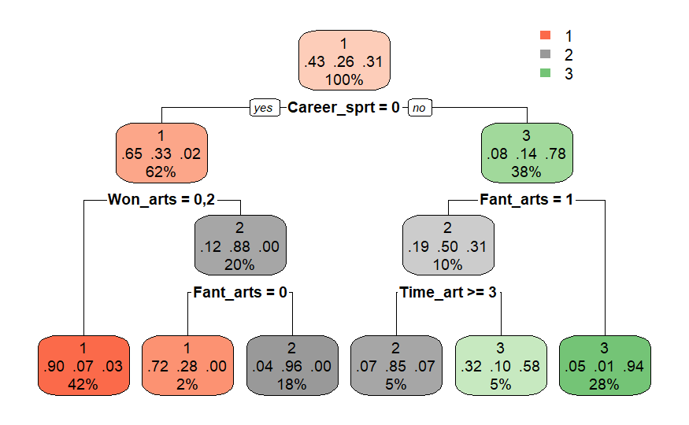

```r
# Plot the decision tree

rpart.plot(Hobby_Data_ctree)
```

```r
NA
NA
NA
NA
NA
NA
```

**Decision Tree Analysis Using Information gain(80/20):**

In Second Tree ,we devide dataset into training set and test set with size(%80,%20) respectively. As you can see in the figure, the root node (“Career_sprt”) serves as the starting point for the classification process since have the heights Gain. The dataset has a distribution of approximately 43%for class1 (“Academics”), 26% for class 2(“Arts”), and 31% for class 3 (“Sports”).

The tree further branches based on the values of the “Career_sprt” if equal 0, tree branches based on”Won_arts” ,and majority of instances fall into “Acadimcs”, constituting 65% , if”Won_arts” equal 0 or2 In this case the tree terminates with a leaf node indicating a high probability 90% for “Acadimcs”.else the instances are classified based on “Fant_arts”into “Arts” with a probability 88%,if equal 0 the instances are classified into “Academics” with a probability of 72% ,else the instances are classified into “Arts” with a high probability 96%, if “Career_sprt” is 1, the tree further branches based on the “Fant_arts” into “Sports” with a probability 78%. If “Fant_arts” is 1 , there is another split based on the “Time_art” into “Arts” with a probability 50%. If “Time_art” is greater than or equal to 3, the instances are classified into “Arts” with a probability of 85% . On the other hand, if “Time_art” is less than 3, the instances are classified into “Sports” with a probability of 58% .If “Fant_arts” If not equal 1 , the instances are classified into “Sports” with a high probability 94%, as indicated by the leaf node.

**Second Confusion matrix**

```r
# Predict on the test data
testPred <- predict(Hobby_Data_ctree, newdata = testData, type = 'class')

# Check the accuracy of the model
accuracy <- sum(testPred == testData$`Predicted Hobby`) / nrow(testData) * 100
cat('Accuracy:', accuracy, '\n')
```

```
Accuracy: 90.56604
```

```r
# Create a confusion matrix
conf_matrix <- table(Actual = testData$`Predicted Hobby`, Predicted = testPred)

# Calculate precision for each class
precision_class_1 <- conf_matrix[1, 1] / sum(conf_matrix[1, ])
precision_class_2 <- conf_matrix[2, 2] / sum(conf_matrix[2, ])
precision_class_3 <- conf_matrix[3, 3] / sum(conf_matrix[3, ])

# Calculate sensitivity for each class
sensitivity_class_1 <- conf_matrix[1, 1] / sum(conf_matrix[1, ])
sensitivity_class_2 <- conf_matrix[2, 2] / sum(conf_matrix[2, ])
sensitivity_class_3 <- conf_matrix[3, 3] / sum(conf_matrix[3, ])

# Calculate specificity for each class
specificity_class_1 <- sum(diag(conf_matrix[-1, -1])) / sum(conf_matrix[-1, ])
specificity_class_2 <- sum(conf_matrix[c(1, 3), c(1, 3)]) / sum(conf_matrix[c(1, 3), ])
specificity_class_3 <- sum(conf_matrix[c(1, 2), c(1, 2)]) / sum(conf_matrix[c(1, 2), ])

# Calculate macro-average sensitivity
macro_avg_sensitivity <- (sensitivity_class_1 + sensitivity_class_2 + sensitivity_class_3) / 3

# Calculate macro-average specificity
macro_avg_specificity <- (specificity_class_1 + specificity_class_2 + specificity_class_3) / 3

# Calculate macro-average precision
macro_avg_precision <- (precision_class_1 + precision_class_2 + precision_class_3) / 3

# Print macro-average sensitivity
cat('Average Sensitivity:', macro_avg_sensitivity, '\n')
```

```
Average Sensitivity: 0.8983021
```

```r
# Print macro-average specificity
cat('Average Specificity:', macro_avg_specificity, '\n')
```

```
Average Specificity: 0.937816
```

```r
# Print macro-average precision
cat('Average Precision:', macro_avg_precision, '\n')
```

```
Average Precision: 0.8983021
```

```r
# Print precision for each class
cat('Precision for Class 1:', precision_class_1, ' \n')
```

```
Precision for Class 1: 0.9319728
```

```r
cat('Precision for Class 2:', precision_class_2, '  \n')
```

```
Precision for Class 2: 0.8607595
```

```r
cat('Precision for Class 3:', precision_class_3, ' \n')
```

```
Precision for Class 3: 0.9021739
```

```r
# Print sensitivity for each class
cat('Sensitivity for Class 1:', sensitivity_class_1, '\n')
```

```
Sensitivity for Class 1: 0.9319728
```

```r
cat('Sensitivity for Class 2:', sensitivity_class_2, '\n')
```

```
Sensitivity for Class 2: 0.8607595
```

```r
cat('Sensitivity for Class 3:', sensitivity_class_3, '\n')
```

```
Sensitivity for Class 3: 0.9021739
```

```r
# Print specificity for each class
cat('Specificity for Class 1:', specificity_class_1, '\n')
```

```
Specificity for Class 1: 0.8830409
```

```r
cat('Specificity for Class 2:', specificity_class_2, '\n')
```

```
Specificity for Class 2: 0.9790795
```

```r
cat('Specificity for Class 3:', specificity_class_3, '\n')
```

```
Specificity for Class 3: 0.9513274
```

**3-Information Gain(90%,10%)**

```r
library(rpart)

library(caTools)
library(rpart.plot)
library(caret)
# Set the seed for reproducibility
set.seed(1234)

# Split the data into training and testing sets
ind <- sample(2, nrow(Hobby_Data), replace=TRUE, prob=c(0.9, 0.1))
trainData <- Hobby_Data[ind == 1,]
testData <- Hobby_Data[ind == 2,]

# Define the formula for the decision tree
myFormula <- `Predicted Hobby` ~ Scholarship + Fav_sub + Projects + Grasp_pow + Time_sprt + Career_sprt + Act_sprt + Fant_arts + Won_arts + Time_art + Olympiad_Participation

# Create the decision tree model with the "information" splitting criterion
Hobby_Data_ctree <- rpart(myFormula, data = trainData, method = "class", parms = list(split = "information"))



# Print the decision tree
print(Hobby_Data_ctree)
```

```
n= 1429

node), split, n, loss, yval, (yprob)
      * denotes terminal node

 1) root 1429 809 1 (0.43386984 0.25052484 0.31560532)
   2) Career_sprt=0 880 304 1 (0.65454545 0.32613636 0.01931818)
     4) Won_arts=0,2 597  58 1 (0.90284757 0.06867672 0.02847571) *
     5) Won_arts=1 283  37 2 (0.13074205 0.86925795 0.00000000)
      10) Fant_arts=0 35   9 1 (0.74285714 0.25714286 0.00000000) *
      11) Fant_arts=1 248  11 2 (0.04435484 0.95564516 0.00000000) *
   3) Career_sprt=1 549 115 3 (0.08014572 0.12932605 0.79052823)
     6) Fant_arts=1 137  71 2 (0.18978102 0.48175182 0.32846715)
      12) Time_art>=2.5 70  11 2 (0.07142857 0.84285714 0.08571429) *
      13) Time_art< 2.5 67  28 3 (0.31343284 0.10447761 0.58208955)
        26) Act_sprt=0 22   9 1 (0.59090909 0.22727273 0.18181818) *
        27) Act_sprt=1 45  10 3 (0.17777778 0.04444444 0.77777778) *
     7) Fant_arts=0 412  23 3 (0.04368932 0.01213592 0.94417476) *
```

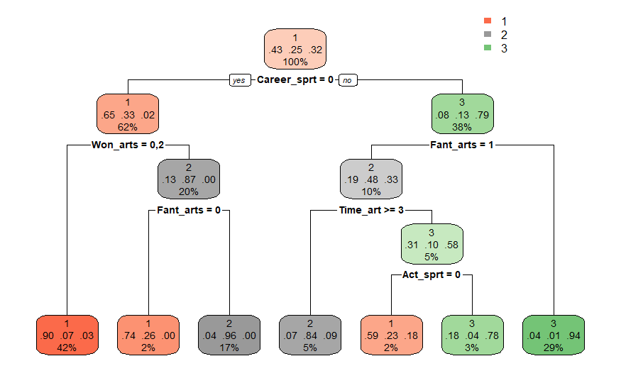

```r
# Plot the decision tree

rpart.plot(Hobby_Data_ctree)
```

```r
NA
NA
NA
NA
```

**Decision Tree Analysis Using Information gain(90/10):**

In Third Tree ,we devide dataset into training set and test set with size(%90,%10) respectively. As you can see in the figure, the root node (“Career_sprt”) serves as the starting point for the classification process since have the heights Gain. The dataset has a distribution of approximately 43% for class 1(“Academics”), 25% for class 2(“Arts”), and 32% for class 3 (“Sports”).

The tree further branches based on the values of the “Career_sprt” if equal 0, tree branches based on”Won_arts” ,and majority of instances fall into “Acadimcs”, constituting 65% , if”Won_arts” equal 0 or 2 In this case the tree terminates with a leaf node indicating a high probability 90% for “Acadimcs”.else the instances are classified based on “Fant_arts”into “Arts” with a probability 87%,if equal 0 the instances are classified into “Academics” with a probability of 74% ,else the instances are classified into “Arts” with a high probability 96%, if “Career_sprt” is 1, the tree further branches based on the “Fant_arts” into “Sports” with a probability 79%. If “Fant_arts” is 1 , there is another split based on the “Time_art” into “Arts” with a probability 48%. If “Time_art” is greater than or equal to 3, the instances are classified into “Arts” with a probability of 84% . On the other hand, if “Time_art” is less than 3, the instances are classified based on”Act_sprt ” into “Sports” with a probability of 58% .if “Act_sprt” equal 0 the instances are classified into “Academics” with a probability of 59%, other hand the instances are classified into “Sports” with a probability of 78%. If “Fant_arts” not equal 1 , the instances are classified into “Sports” with a high probability 94%, as indicated by the leaf node.

**Third Confusion matrix**

```r
# Predict on the test data
testPred <- predict(Hobby_Data_ctree, newdata = testData, type = 'class')

# Check the accuracy of the model
accuracy <- sum(testPred == testData$`Predicted Hobby`) / nrow(testData) * 100
cat('Accuracy:', accuracy, '\n')
```

```
Accuracy: 87.2093
```

```r
# Create a confusion matrix
conf_matrix <- table(Actual = testData$`Predicted Hobby`, Predicted = testPred)

# Calculate precision for each class
precision_class_1 <- conf_matrix[1, 1] / sum(conf_matrix[1, ])
precision_class_2 <- conf_matrix[2, 2] / sum(conf_matrix[2, ])
precision_class_3 <- conf_matrix[3, 3] / sum(conf_matrix[3, ])

# Calculate sensitivity for each class
sensitivity_class_1 <- conf_matrix[1, 1] / sum(conf_matrix[1, ])
sensitivity_class_2 <- conf_matrix[2, 2] / sum(conf_matrix[2, ])
sensitivity_class_3 <- conf_matrix[3, 3] / sum(conf_matrix[3, ])

# Calculate specificity for each class
specificity_class_1 <- sum(diag(conf_matrix[-1, -1])) / sum(conf_matrix[-1, ])
specificity_class_2 <- sum(conf_matrix[c(1, 3), c(1, 3)]) / sum(conf_matrix[c(1, 3), ])
specificity_class_3 <- sum(conf_matrix[c(1, 2), c(1, 2)]) / sum(conf_matrix[c(1, 2), ])

# Calculate macro-average sensitivity
macro_avg_sensitivity <- (sensitivity_class_1 + sensitivity_class_2 + sensitivity_class_3) / 3

# Calculate macro-average specificity
macro_avg_specificity <- (specificity_class_1 + specificity_class_2 + specificity_class_3) / 3

# Calculate macro-average precision
macro_avg_precision <- (precision_class_1 + precision_class_2 + precision_class_3) / 3

# Print macro-average sensitivity
cat('Average Sensitivity:', macro_avg_sensitivity, '\n')
```

```
Average Sensitivity: 0.856641
```

```r
# Print macro-average specificity
cat('Average Specificity:', macro_avg_specificity, '\n')
```

```
Average Specificity: 0.9190518
```

```r
# Print macro-average precision
cat('Average Precision:', macro_avg_precision, '\n')
```

```
Average Precision: 0.856641
```

```r
# Print precision for each class
cat('Precision for Class 1:', precision_class_1, ' \n')
```

```
Precision for Class 1: 0.9240506
```

```r
cat('Precision for Class 2:', precision_class_2, '  \n')
```

```
Precision for Class 2: 0.8653846
```

```r
cat('Precision for Class 3:', precision_class_3, ' \n')
```

```
Precision for Class 3: 0.7804878
```

```r
# Print sensitivity for each class
cat('Sensitivity for Class 1:', sensitivity_class_1, '\n')
```

```
Sensitivity for Class 1: 0.9240506
```

```r
cat('Sensitivity for Class 2:', sensitivity_class_2, '\n')
```

```
Sensitivity for Class 2: 0.8653846
```

```r
cat('Sensitivity for Class 3:', sensitivity_class_3, '\n')
```

```
Sensitivity for Class 3: 0.7804878
```

```r
# Print specificity for each class
cat('Specificity for Class 1:', specificity_class_1, '\n')
```

```
Specificity for Class 1: 0.827957
```

```r
cat('Specificity for Class 2:', specificity_class_2, '\n')
```

```
Specificity for Class 2: 0.975
```

```r
cat('Specificity for Class 3:', specificity_class_3, '\n')
```

```
Specificity for Class 3: 0.9541985
```

**Comparing Decision Tree Results Using Infromation gain:** After training three trees with different sizes, employing information gain as the selection measure, our analysis led to consistent accuracy results among the trees: Tree 1 (0.8932), Tree 2 (0.9057), and Tree 3 (0.8721). The minor discrepancies observed in these accuracy values could be attributed to the variations in dataset sizes. Investigating the impact of different training set sizes on model performance offers valuable insights into the intricate relationship between data size and accuracy.

In the case of Tree 2, where a larger training set was employed (80% training, 20% testing), the model had the opportunity to grasp more robust patterns and relationships within the data. However, it is crucial to underscore the necessity of striking a balance between the sizes of the training and testing sets. For Tree 3, with a relatively smaller testing set (90% training, 10% testing), the accuracy estimate might be less reliable due to the limited sample size in the testing set.

**Gini index**

The Gini index, is a measure used in decision trees, specifically in the CART (Classification and Regression Trees) algorithm, to quantify how often a randomly chosen element would be incorrectly labeled if it was randomly labeled according to the distribution of labels in the subset. It reflects the probability of a particular variable being wrongly classified when it is randomly chosen.[5]

**1-Gini index(80%,20%)**

Install necessary libraries

```r
install.packages("rpart")
install.packages("rpart.plot")
install.packages("caTools")
install.packages("caret")
```

Load necessary libraries

```r
library(rpart)
library(rpart.plot)
library(caTools)
library(caret)
```

Set a seed for reproducibility

```r
set.seed(123)
```

Split the dataset, 80% for training, 20% for testing

```r
split <- sample.split(Hobby_Data$`Predicted Hobby`, SplitRatio = 0.80)
```

Create the training set (80% of the data)

```r
training_set <- subset(Hobby_Data, split == TRUE)
```

Create the test set (20% of the data)

```r
test_set <- subset(Hobby_Data, split == FALSE)
```

Build a decision tree model on the training set

```r
tree <- rpart(`Predicted Hobby` ~ ., data = training_set, method = 'class')
```

Make predictions on the test set using the tree model

```r
predictions <- predict(tree, test_set, type = "class")
```

Confusion matrix

```r
conf_matrix <- table(Predicted = predictions, Actual = test_set$`Predicted Hobby`)
```

Calculate accuracy

```r
accuracy <- sum(diag(conf_matrix)) / sum(conf_matrix)
```

Initialize vectors to hold the metrics for each class

```r
precision <- numeric(length = nrow(conf_matrix))
recall <- numeric(length = nrow(conf_matrix))
specificity <- numeric(length = nrow(conf_matrix))
```

Calculate metrics for each class

```r
for (i in 1:nrow(conf_matrix)) {
  TP <- conf_matrix[i, i]
  FP <- sum(conf_matrix[, i]) - TP
  FN <- sum(conf_matrix[i, ]) - TP
  TN <- sum(conf_matrix) - TP - FP - FN

  precision[i] <- TP / (TP + FP)
  recall[i] <- TP / (TP + FN)
  specificity[i] <- TN / (TN + FP)
}
```

Average the metrics if you want a single performance measure

```r
avg_precision <- mean(precision)
avg_recall <- mean(recall)
avg_specificity <- mean(specificity)
```

Output the evaluation metrics

```r
print(paste("Overall Accuracy:", accuracy))
```

```
[1] "Overall Accuracy: 0.90625"
```

```r
print(paste("Average Precision:", avg_precision))
```

```
[1] "Average Precision: 0.90458768873403"
```

```r
print(paste("Average Recall (Sensitivity):", avg_recall))
```

```
[1] "Average Recall (Sensitivity): 0.909234717489167"
```

```r
print(paste("Average Specificity:", avg_specificity))
```

```
[1] "Average Specificity: 0.95154501649595"
```

the metrics for each class:

```r
metrics <- data.frame(
  Class = rownames(conf_matrix),
  Precision = precision,
  Recall = recall,
  Specificity = specificity
)
```

Print metrics

```r
print(metrics)
```

| Class | Precision | Recall | Specificity |
| --- | --- | --- | --- |
| 1 | 0.9071429 | 0.9136691 | 0.9281768 |
| 2 | 0.8780488 | 0.9473684 | 0.9590164 |
| 3 | 0.9285714 | 0.8666667 | 0.9674419 |

```r
NA
```

Plot the decision tree

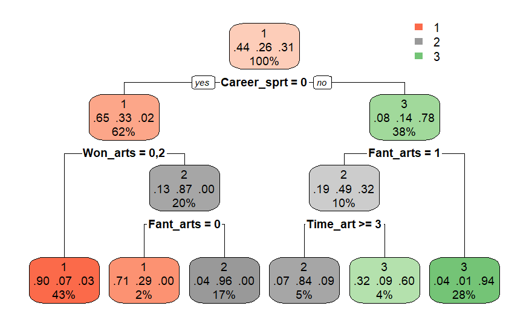

```r
rpart.plot(tree)
```

**2-Gini index(90%,10%)**

Install necessary libraries

```r
install.packages("rpart")
install.packages("rpart.plot")
install.packages("caTools")
install.packages("caret")
```

Load necessary libraries

```r
library(rpart)
library(rpart.plot)
library(caTools)
library(caret)
```

Set a seed for reproducibility

```r
set.seed(123)
```

Split the dataset, 90% for training, 10% for testing

```r
split <- sample.split(Hobby_Data$`Predicted Hobby`, SplitRatio = 0.90)
```

Create the training set (90% of the data)

```r
training_set <- subset(Hobby_Data, split == TRUE)
```

Create the test set (10% of the data)

```r
test_set <- subset(Hobby_Data, split == FALSE)
```

Build a decision tree model on the training set

```r
tree <- rpart(`Predicted Hobby` ~ ., data = training_set, method = 'class')
```

Make predictions on the test set using the tree model

```r
predictions <- predict(tree, test_set, type = "class")
```

Confusion matrix

```r
conf_matrix <- table(Predicted = predictions, Actual = test_set$`Predicted Hobby`)
```

Calculate accuracy

```r
accuracy <- sum(diag(conf_matrix)) / sum(conf_matrix)
```

Initialize vectors to hold the metrics for each class

```r
precision <- numeric(length = nrow(conf_matrix))
recall <- numeric(length = nrow(conf_matrix))
specificity <- numeric(length = nrow(conf_matrix))
```

Calculate metrics for each class

```r
for (i in 1:nrow(conf_matrix)) {
  TP <- conf_matrix[i, i]
  FP <- sum(conf_matrix[, i]) - TP
  FN <- sum(conf_matrix[i, ]) - TP
  TN <- sum(conf_matrix) - TP - FP - FN

  precision[i] <- TP / (TP + FP)
  recall[i] <- TP / (TP + FN)
  specificity[i] <- TN / (TN + FP)
}
```

Average the metrics if you want a single performance measure

```r
avg_precision <- mean(precision)
avg_recall <- mean(recall)
avg_specificity <- mean(specificity)
```

Output the evaluation metrics

```r
print(paste("Overall Accuracy:", accuracy))
```

```
[1] "Overall Accuracy: 0.91875"
```

```r
print(paste("Average Precision:", avg_precision))
```

```
[1] "Average Precision: 0.918500082960013"
```

```r
print(paste("Average Recall (Sensitivity):", avg_recall))
```

```
[1] "Average Recall (Sensitivity): 0.919272982536024"
```

```r
print(paste("Average Specificity:", avg_specificity))
```

```
[1] "Average Specificity: 0.957895791426138"
```

the metrics for each class:

```r
metrics <- data.frame(
  Class = rownames(conf_matrix),
  Precision = precision,
  Recall = recall,
  Specificity = specificity
)
```

Print metrics

```r
print(metrics)
```

| Class | Precision | Recall | Specificity |
| --- | --- | --- | --- |
| 1 | 0.9142857 | 0.9411765 | 0.9347826 |
| 2 | 0.9024390 | 0.9487179 | 0.9669421 |
| 3 | 0.9387755 | 0.8679245 | 0.9719626 |

```r
NA
```

Plot the decision tree

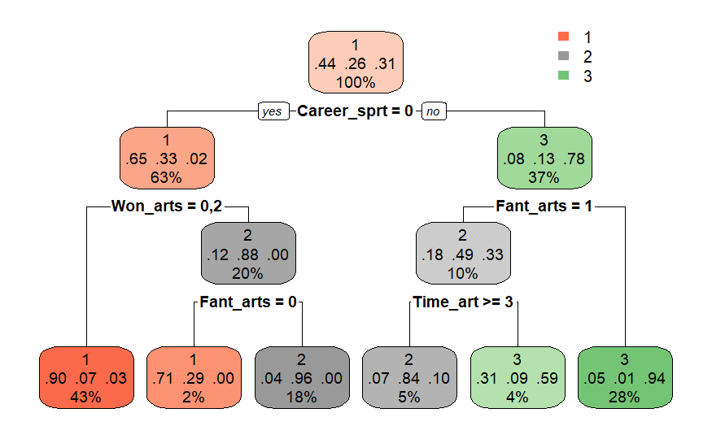

```r
rpart.plot(tree)
```

**3-Gini index(70%,30%)**

Install necessary libraries

```r
install.packages("rpart")
install.packages("rpart.plot")
install.packages("caTools")
install.packages("caret")
```

Load necessary libraries

```r
library(rpart)
library(rpart.plot)
library(caTools)
library(caret)
```

Set a seed for reproducibility

```r
set.seed(123)
```

Split the dataset, 70% for training, 30% for testing

```r
split <- sample.split(Hobby_Data$`Predicted Hobby`, SplitRatio = 0.70)
```

Create the training set (70% of the data)

```r
training_set <- subset(Hobby_Data, split == TRUE)
```

```r
test_set <- subset(Hobby_Data, split == FALSE)
```

Build a decision tree model on the training set

```r
tree <- rpart(`Predicted Hobby` ~ ., data = training_set, method = 'class')
```

Make predictions on the test set using the tree model

```r
predictions <- predict(tree, test_set, type = "class")
```

Confusion matrix

```r
conf_matrix <- table(Predicted = predictions, Actual = test_set$`Predicted Hobby`)
```

Calculate accuracy

```r
accuracy <- sum(diag(conf_matrix)) / sum(conf_matrix)
```

Initialize vectors to hold the metrics for each class

```r
precision <- numeric(length = nrow(conf_matrix))
recall <- numeric(length = nrow(conf_matrix))
specificity <- numeric(length = nrow(conf_matrix))
```

Calculate metrics for each class

```r
for (i in 1:nrow(conf_matrix)) {
  TP <- conf_matrix[i, i]
  FP <- sum(conf_matrix[, i]) - TP
  FN <- sum(conf_matrix[i, ]) - TP
  TN <- sum(conf_matrix) - TP - FP - FN

  precision[i] <- TP / (TP + FP)
  recall[i] <- TP / (TP + FN)
  specificity[i] <- TN / (TN + FP)
}
```

Average the metrics if you want a single performance measure

```r
avg_precision <- mean(precision)
avg_recall <- mean(recall)
avg_specificity <- mean(specificity)
```

Output the evaluation metrics

```r
print(paste("Overall Accuracy:", accuracy))
```

```
[1] "Overall Accuracy: 0.910602910602911"
```

```r
print(paste("Average Precision:", avg_precision))
```

```
[1] "Average Precision: 0.909378367914953"
```

```r
print(paste("Average Recall (Sensitivity):", avg_recall))
```

```
[1] "Average Recall (Sensitivity): 0.911940703451739"
```

```r
print(paste("Average Specificity:", avg_specificity))
```

```
[1] "Average Specificity: 0.953670224578741"
```

the metrics for each class:

```r
metrics <- data.frame(
  Class = rownames(conf_matrix),
  Precision = precision,
  Recall = recall,
  Specificity = specificity
)
```

Print metrics

```r
print(metrics)
```

| Class | Precision | Recall | Specificity |
| --- | --- | --- | --- |
| 1 | 0.9095238 | 0.9138756 | 0.9301471 |
| 2 | 0.8861789 | 0.9316239 | 0.9615385 |
| 3 | 0.9324324 | 0.8903226 | 0.9693252 |

```r
NA
```

Plot the decision tree

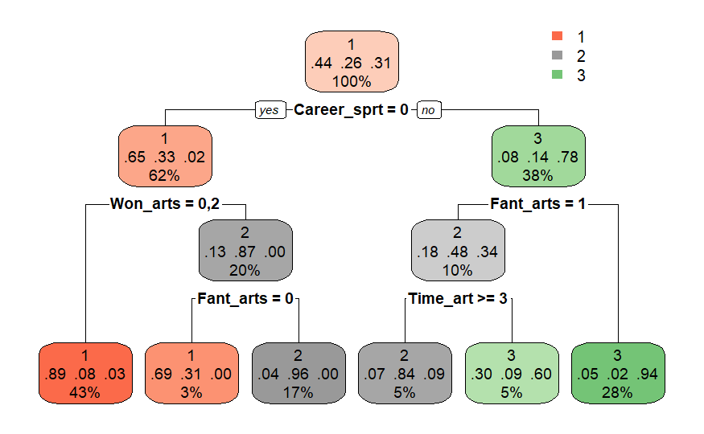

```r
rpart.plot(tree)
```

**Comparing Decision Tree Results Using Gini Index:**

Across Three Training-Test Sizes: The results of the decision trees from the 90/10, 80/20, and 70/30 dataset splits, there is a consistent pattern: ‘Career_sprt’ is always the root node, and the subsequent splits on ‘Won_arts’ and ‘Fant_arts’ are the same across all trees. This consistency in tree structure and the probabilities for predicting ‘Academics’ and ‘Sports’ across different splits suggest a stable and robust model that is reliable regardless of the training set size.

the accuracies of three data splits reveals distinct outcomes: the (90,10) split leads with the highest accuracy at 0.91875, suggesting that a larger training portion is more effective in this case. The (70,30) split follows with an accuracy of 0.91060, showing strong performance even with a larger test set. However, the commonly used (80,20) split lags slightly behind, achieving an accuracy of 0.90625. This comparison highlights the impact of varying training and testing proportions on model accuracy.

| Gini index | 90 %t raining set 10% testing set: | 80 %t raining set 20% testing set: | 70 %t raining set 30% testing set: |
| --- | --- | --- | --- |
| **Accuracy** | 0.91875 | 0.906 | 0.911 |
| **precision** | 0.91850 | 0.905 | 0.909 |
| **sensitivity** | 0.91927 | 0.909 | 0.912 |
| **specificity** | 0.9578 | 0.952 | 0.954 |

**Gain Ratio** The third criterion employed for building the decision tree is Gain Ratio. Gain Ratio stands out as a significant metric in decision tree algorithms, especially in scenarios involving categorical target variables. It normalizes the reduction in entropy by taking into account the potential information content of the feature. This normalization process makes Gain Ratio particularly suitable for datasets with categorical target variables. By factoring in the intrinsic information of a split, Gain Ratio effectively mitigates bias towards features with higher levels, ensuring a more balanced evaluation of different attributes.[6]

**1-Gain ratio(90%,10%)**

Install necessary libraries

```r
install.packages("C50")
install.packages("printr")
install.packages("caret")
```

Load necessary libraries

```r
library(C50)
library(printr)
library(caret)
```

Set a seed for reproducibility

```r
set.seed(1958)
```

Splitting the data into training and test sets

```r
train_indices <- sample(1:nrow(Hobby_Data), 0.9 * nrow(Hobby_Data))
Hobby.train <- Hobby_Data[train_indices, ]
Hobby.test <- Hobby_Data[-train_indices, ]
```

Training the decision tree model

```r
model <- C5.0(`Predicted Hobby` ~ ., data = Hobby.train, control = C5.0Control(CF = 0.01))
```

Making predictions on the test set

```r
predictions <- predict(model, newdata = Hobby.test, type = 'class')
```

Create a confusion matrix from the predictions and actual values

```r
conf_matrix <- table(Predicted = predictions, Actual = Hobby.test$`Predicted Hobby`)
```

Calculate and print the accuracy of the model

```r
accuracy <- sum(diag(conf_matrix)) / sum(conf_matrix)
print(paste('Accuracy on test data is:', accuracy))
```

```
[1] "Accuracy on test data is: 0.894409937888199"
```

Initialize vectors to hold the metrics for each class

```r
precision <- numeric(length = nrow(conf_matrix))
recall <- numeric(length = nrow(conf_matrix))
specificity <- numeric(length = nrow(conf_matrix))
```

Calculate metrics for each class

```r
for (i in 1:nrow(conf_matrix)) {
  TP <- conf_matrix[i, i]
  FP <- sum(conf_matrix[, i]) - TP
  FN <- sum(conf_matrix[i, ]) - TP
  TN <- sum(conf_matrix) - TP - FP - FN

  precision[i] <- TP / (TP + FP)
  recall[i] <- TP / (TP + FN)
  specificity[i] <- TN / (TN + FP)
}
```

Average the metrics if you want a single performance measure

```r
avg_precision <- mean(precision)
avg_recall <- mean(recall)
avg_specificity <- mean(specificity)
```

Output the evaluation metrics

```r
print(paste("Overall Accuracy:", accuracy))
```

```
[1] "Overall Accuracy: 0.894409937888199"
```

```r
print(paste("Average Precision:", avg_precision))
```

```
[1] "Average Precision: 0.887116639229315"
```

```r
print(paste("Average Recall (Sensitivity):", avg_recall))
```

```
[1] "Average Recall (Sensitivity): 0.900716845878136"
```

```r
print(paste("Average Specificity:", avg_specificity))
```

```
[1] "Average Specificity: 0.945410365212345"
```

print the metrics for each class:

```r
metrics <- data.frame(
  Class = rownames(conf_matrix),
  Precision = precision,
  Recall = recall,
  Specificity = specificity
)
```

Print metrics

```r
print(metrics)
```

| Class | Precision | Recall | Specificity |
| --- | --- | --- | --- |
| 1 | 0.8873239 | 0.9000000 | 0.9120879 |
| 2 | 0.8285714 | 0.9354839 | 0.9538462 |
| 3 | 0.9454545 | 0.8666667 | 0.9702970 |

Generate and print additional performance metrics using caret package

```r
confusionMatrix(predictions, Hobby.test$`Predicted Hobby`)
```

```
Confusion Matrix and Statistics

          Reference
Prediction  1  2  3
         1 63  5  2
         2  1 29  1
         3  7  1 52

Overall Statistics

               Accuracy : 0.8944
                 95% CI : (0.8363, 0.9373)
    No Information Rate : 0.441
    P-Value [Acc > NIR] : <2e-16

                  Kappa : 0.8348

 Mcnemar's Test P-Value : 0.142

Statistics by Class:

                     Class: 1 Class: 2 Class: 3
Sensitivity            0.8873   0.8286   0.9455
Specificity            0.9222   0.9841   0.9245
Pos Pred Value         0.9000   0.9355   0.8667
Neg Pred Value         0.9121   0.9538   0.9703
Prevalence             0.4410   0.2174   0.3416
Detection Rate         0.3913   0.1801   0.3230
Detection Prevalence   0.4348   0.1925   0.3727
Balanced Accuracy      0.9048   0.9063   0.9350
```

Plot the decision tree

[figure not shown]

```r
plot(model)
```

**Decision Tree Analysis Using Gain Ratio(90%/10%):**

In First Tree ,we devide dataset into training set and test set with size(%90,%10) respectively. As you can see in the figure, the root node is “Career_sprt” , class 1(“Academics”), class 2(“Arts”), and class 3 (“Sports”).

Node “Career_sprt” The first decision is based on whether the value of the “Career_sprt” attribute is 0. then check if “Won_arts” is either 0 or 2.If” Won_arts” is 0 or 2 , predict”Academic”.then check If “Fant_arts” is 1 “and Won_arts” is 1, predict “Arts”.If “Fant_arts” is 0 and Won_arts is 0 or 2, then check if Olympiad_Participation is 1.If Olympiad_Participation is 1 predict “Academics”.(When Olympiad_Participation is 0) If “Olympiad_Participation” is 0 and “Fant_arts” is 0, then check if “Grasp_pow” is less than or equal to 4 , predict class”Arts”.When Career_sprt is 1, then check if “Fant_arts” is 0 then predict “Sports”. If “Fant_arts” is 1, then check if “Time_art” is greater than 2.check if “Time_art” is less than or equal to 2, then check if “Act_sprt” is 1 or 0.If Act_sprt is 1, predict “Sports”. If Act_sprt is 0, then check if Olympiad_Participation is 0 predict “Arts”. If “Olympiad_Participation” is 1, predict “Academics”.When Time_art is greater than 2 ,If Won_arts is 0, predict class “Sports”.

**2-Gain ratio(80%,20%)**

Install necessary libraries

```r
install.packages("C50")
install.packages("printr")
install.packages("caret")
```

Load necessary libraries

```r
library(C50)
library(printr)
library(caret)
```

Set a seed for reproducibility

```r
set.seed(1958)
```

Splitting the data into training and test sets

```r
train_indices <- sample(1:nrow(Hobby_Data), 0.8 * nrow(Hobby_Data))
Hobby.train <- Hobby_Data[train_indices, ]
Hobby.test <- Hobby_Data[-train_indices, ]
```

Training the decision tree model

```r
model <- C5.0(`Predicted Hobby` ~ ., data = Hobby.train, control = C5.0Control(CF = 0.01))
```

Making predictions on the test set

```r
predictions <- predict(model, newdata = Hobby.test, type = 'class')
```

Create a confusion matrix from the predictions and actual values

```r
conf_matrix <- table(Predicted = predictions, Actual = Hobby.test$`Predicted Hobby`)
```

Calculate and print the accuracy of the model

```r
accuracy <- sum(diag(conf_matrix)) / sum(conf_matrix)
print(paste('Accuracy on test data is:', accuracy))
```

```
[1] "Accuracy on test data is: 0.88785046728972"
```

Initialize vectors to hold the metrics for each class

```r
precision <- numeric(length = nrow(conf_matrix))
recall <- numeric(length = nrow(conf_matrix))
specificity <- numeric(length = nrow(conf_matrix))
```

Calculate metrics for each class

```r
for (i in 1:nrow(conf_matrix)) {
  TP <- conf_matrix[i, i]
  FP <- sum(conf_matrix[, i]) - TP
  FN <- sum(conf_matrix[i, ]) - TP
  TN <- sum(conf_matrix) - TP - FP - FN

  precision[i] <- TP / (TP + FP)
  recall[i] <- TP / (TP + FN)
  specificity[i] <- TN / (TN + FP)
}
```

Average the metrics if you want a single performance measure

```r
avg_precision <- mean(precision)
avg_recall <- mean(recall)
avg_specificity <- mean(specificity)
```

Output the evaluation metrics

```r
print(paste("Overall Accuracy:", accuracy))
```

```
[1] "Overall Accuracy: 0.88785046728972"
```

```r
print(paste("Average Precision:", avg_precision))
```

```
[1] "Average Precision: 0.881128647842008"
```

```r
print(paste("Average Recall (Sensitivity):", avg_recall))
```

```
[1] "Average Recall (Sensitivity): 0.890113905007522"
```

```r
print(paste("Average Specificity:", avg_specificity))
```

```
[1] "Average Specificity: 0.942591788366981"
```

print the metrics for each class:

```r
metrics <- data.frame(
  Class = rownames(conf_matrix),
  Precision = precision,
  Recall = recall,
  Specificity = specificity
)
```

Print metrics

```r
print(metrics)
```

| Class | Precision | Recall | Specificity |
| --- | --- | --- | --- |
| 1 | 0.8985507 | 0.8794326 | 0.9222222 |
| 2 | 0.8289474 | 0.9000000 | 0.9482072 |
| 3 | 0.9158879 | 0.8909091 | 0.9573460 |

Generate and print additional performance metrics using caret package

```r
confusionMatrix(predictions, Hobby.test$`Predicted Hobby`)
```

```
Confusion Matrix and Statistics

          Reference
Prediction   1   2   3
         1 124  10   7
         2   5  63   2
         3   9   3  98

Overall Statistics

               Accuracy : 0.8879
                 95% CI : (0.8481, 0.9202)
    No Information Rate : 0.4299
    P-Value [Acc > NIR] : <2e-16

                  Kappa : 0.8262

 Mcnemar's Test P-Value : 0.5485

Statistics by Class:

                     Class: 1 Class: 2 Class: 3
Sensitivity            0.8986   0.8289   0.9159
Specificity            0.9071   0.9714   0.9439
Pos Pred Value         0.8794   0.9000   0.8909
Neg Pred Value         0.9222   0.9482   0.9573
Prevalence             0.4299   0.2368   0.3333
Detection Rate         0.3863   0.1963   0.3053
Detection Prevalence   0.4393   0.2181   0.3427
Balanced Accuracy      0.9028   0.9002   0.9299
```

Plot the decision tree

[figure not shown]

```r
plot(model)
```

**3-Gain ratio(70%,30%)**

Install necessary libraries

```r
install.packages("C50")
```

```
Error in install.packages : Updating loaded packages
```

```r
install.packages("printr")
```

```
Error in install.packages : Updating loaded packages
```

```r
install.packages("caret")
```

```
Error in install.packages : Updating loaded packages
```

Load necessary libraries

```r
library(C50)
library(printr)
library(caret)
```

Set a seed for reproducibility

```r
set.seed(1958)
```

Splitting the data into training and test sets

```r
train_indices <- sample(1:nrow(Hobby_Data), 0.7 * nrow(Hobby_Data))
Hobby.train <- Hobby_Data[train_indices, ]
Hobby.test <- Hobby_Data[-train_indices, ]
```

Training the decision tree model

```r
model <- C5.0(`Predicted Hobby` ~ ., data = Hobby.train, control = C5.0Control(CF = 0.01))
```

Making predictions on the test set

```r
predictions <- predict(model, newdata = Hobby.test, type = 'class')
```

Create a confusion matrix from the predictions and actual values

```r
conf_matrix <- table(Predicted = predictions, Actual = Hobby.test$`Predicted Hobby`)
```

Calculate and print the accuracy of the model

```r
accuracy <- sum(diag(conf_matrix)) / sum(conf_matrix)
print(paste('Accuracy on test data is:', accuracy))
```

```
[1] "Accuracy on test data is: 0.893970893970894"
```

Initialize vectors to hold the metrics for each class

```r
precision <- numeric(length = nrow(conf_matrix))
recall <- numeric(length = nrow(conf_matrix))
specificity <- numeric(length = nrow(conf_matrix))
```

Calculate metrics for each class

```r
for (i in 1:nrow(conf_matrix)) {
  TP <- conf_matrix[i, i]
  FP <- sum(conf_matrix[, i]) - TP
  FN <- sum(conf_matrix[i, ]) - TP
  TN <- sum(conf_matrix) - TP - FP - FN

  precision[i] <- TP / (TP + FP)
  recall[i] <- TP / (TP + FN)
  specificity[i] <- TN / (TN + FP)
}
```

Average the metrics if you want a single performance measure

```r
avg_precision <- mean(precision)
avg_recall <- mean(recall)
avg_specificity <- mean(specificity)
```

Output the evaluation metrics

```r
print(paste("Overall Accuracy:", accuracy))
```

```
[1] "Overall Accuracy: 0.893970893970894"
```

```r
print(paste("Average Precision:", avg_precision))
```

```
[1] "Average Precision: 0.889795821775517"
```

```r
print(paste("Average Recall (Sensitivity):", avg_recall))
```

```
[1] "Average Recall (Sensitivity): 0.902493492712765"
```

```r
print(paste("Average Specificity:", avg_specificity))
```

```
[1] "Average Specificity: 0.946643423571233"
```

print the metrics for each class:

```r
metrics <- data.frame(
  Class = rownames(conf_matrix),
  Precision = precision,
  Recall = recall,
  Specificity = specificity
)
```

Print metrics

```r
print(metrics)
```

| Class | Precision | Recall | Specificity |
| --- | --- | --- | --- |
| 1 | 0.9035533 | 0.8682927 | 0.9311594 |
| 2 | 0.8307692 | 0.9557522 | 0.9402174 |
| 3 | 0.9350649 | 0.8834356 | 0.9685535 |

Generate and print additional performance metrics using caret package

```r
confusionMatrix(predictions, Hobby.test$`Predicted Hobby`)
```

```
Confusion Matrix and Statistics

          Reference
Prediction   1   2   3
         1 178  18   9
         2   4 108   1
         3  15   4 144

Overall Statistics

               Accuracy : 0.894
                 95% CI : (0.863, 0.92)
    No Information Rate : 0.4096
    P-Value [Acc > NIR] : <2e-16

                  Kappa : 0.8377

 Mcnemar's Test P-Value : 0.0067

Statistics by Class:

                     Class: 1 Class: 2 Class: 3
Sensitivity            0.9036   0.8308   0.9351
Specificity            0.9049   0.9858   0.9419
Pos Pred Value         0.8683   0.9558   0.8834
Neg Pred Value         0.9312   0.9402   0.9686
Prevalence             0.4096   0.2703   0.3202
Detection Rate         0.3701   0.2245   0.2994
Detection Prevalence   0.4262   0.2349   0.3389
Balanced Accuracy      0.9042   0.9083   0.9385
```

Plot the decision tree

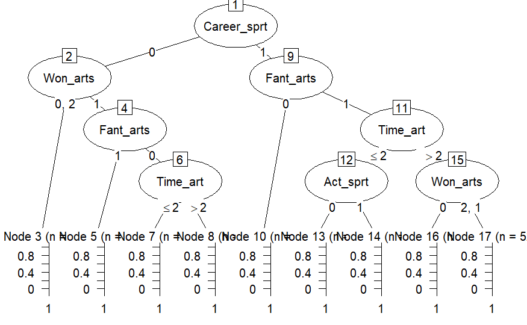

```r
plot(model)
```

**Decision Tree Analysis Using Gain Ratio(70%/30%):**

In Third Tree ,we devide dataset into training set and test set with size(%70,%30) respectively. As you can see in the figure, the root node is “Career_sprt” , class 1(“Academics”), class 2(“Arts”), and class 3 (“Sports”).

The first decision is based on whether the value of the “Career_sprt” attribute is 0.If “Career_sprt” is 0, then check if “Won_arts” is either 0 or 2.predict “Academics”.If “Won_arts” is 1, then check if “Fant_arts” is 1,predict “Arts”.If ““Fant_arts is 0 and”Won_arts” is 0 or 2, then check if “Time_art” is less than or equal to 2,predict “Academics”. If “Time_art” is greater than 2, predict “Arts”.

If “Career_sprt”is 1, then check if “Fant_arts” is 0, predict “Sports”.If “Fant_arts”is 1, then check if “Time_art” is less than or equal to 2 check if “Act_sprt” is 0,predict “Academics” .If “Act_sprt” is 1 predict “Sports”. if “Time_art” is greater than 2, then check if “Won_arts” is 0 predict “Sports”.If “Won_arts” is 1 or 2 predict “Arts”.

**Comparing Decision Tree Results Using Gain Ratio**

Across Three Training-Test Sizes: The accuracy rates -0.8944 for the 90:10 split, 0.8939 for the 70:30 split, and 0.8879 for the 80:20 split – indicate only slight variations, with the 90:10 split being marginally better.

[output not shown]

**#2#Clustering**

first we use Hobby_proc that is version of Hobby data after pre-processing

```r
str(Hobby_proc)
```

```
tibble [1,601 × 12] (S3: tbl_df/tbl/data.frame)
 $ Olympiad_Participation: num [1:1601] 1 1 1 1 1 1 1 1 1 1 ...
 $ Scholarship           : num [1:1601] 1 1 1 1 1 1 1 1 1 1 ...
 $ Fav_sub               : num [1:1601] 2 2 1 2 1 2 1 2 1 1 ...
 $ Projects              : num [1:1601] 1 1 1 1 1 1 1 0 1 1 ...
 $ Grasp_pow             : num [1:1601] 5 3 5 5 5 6 3 5 3 5 ...
 $ Time_sprt             : num [1:1601] 1 2 1 1 3 2 5 2 2 3 ...
 $ Career_sprt           : num [1:1601] 0 0 0 0 0 0 0 0 0 0 ...
 $ Act_sprt              : num [1:1601] 0 0 0 0 0 0 0 0 0 0 ...
 $ Fant_arts             : num [1:1601] 0 0 0 0 0 0 0 0 0 0 ...
 $ Won_arts              : num [1:1601] 2 0 0 2 0 0 0 2 0 0 ...
 $ Time_art              : num [1:1601] 3 1 1 3 2 4 2 3 1 1 ...
 $ Predicted Hobby       : num [1:1601] 1 1 1 1 1 1 1 1 1 1 ...
```

**To convert type from factor columns to numeric**

```r
Hobby_proc$Fav_sub <-as.numeric(Hobby_proc$Fav_sub)

Hobby_proc$Olympiad_Participation <-as.numeric(Hobby_proc$Olympiad_Participation)

Hobby_proc$Projects <-as.numeric(Hobby_proc$Projects)

Hobby_proc$Scholarship <-as.numeric(Hobby_proc$Scholarship)

Hobby_proc$Career_sprt <-as.numeric(Hobby_proc$Career_sprt)

Hobby_proc$Act_sprt <-as.numeric(Hobby_proc$Act_sprt)

Hobby_proc$Fant_arts <-as.numeric(Hobby_proc$Fant_arts)

Hobby_proc$Won_arts <-as.numeric(Hobby_proc$Won_arts)

Hobby_proc$`Predicted Hobby` <-as.numeric(Hobby_proc$`Predicted Hobby` )
```

**Scaled All Columns**

```r
Hobby_proc <-scale(Hobby_proc)
```

```r
Hobby_Data2 <- Hobby_proc[, !(colnames(Hobby_proc) %in% c("Predict Hobby"))]
```

Our data set exhibits a balanced distribution among class labels, with “academic,” “art,” and “sport” constituting 43.6%, 25.6%, and 30.8% of the total, respectively. This balanced distribution is advantageous for both classification and clustering tasks. In classification, a balanced data set helps prevent the model from favoring one class over the others, ensuring that the learning algorithm is exposed to a representative set of examples from each category. This balance promotes the development of a model that generalizes well across all classes, enhancing its predictive performance on new, unseen data. In clustering, a balanced data set aids in forming clusters that are more evenly distributed, allowing for a comprehensive understanding of patterns and relationships across diverse categories. Balanced data sets often lead to more accurate and fair clustering results, enabling meaningful insights into the underlying structures within each class.

**require packages/Library**

```r
install.packages("ggplot2")
```

```
Error in install.packages : Updating loaded packages
```

```r
install.packages("magrittr")
```

```
Error in install.packages : Updating loaded packages
```

```r
install.packages("dplyr")
```

```
Error in install.packages : Updating loaded packages
```

```r
library(factoextra)
library(cluster)
library(dplyr)
```

**k-mean clustering**

**Validation:** Determining the right number of clusters before starting the clustering process is like making sure you have the correct-sized puzzle pieces before putting the puzzle together. It’s important because some clustering algorithms, like K-means, require such a parameter. In addition to that, it helps make the clustering more accurate and useful. If you know the right number beforehand, it saves time and helps make the whole process more efficient and the results more reliable.[8]

**compute average silhouette for k clusters using silhouette() For k-mean**

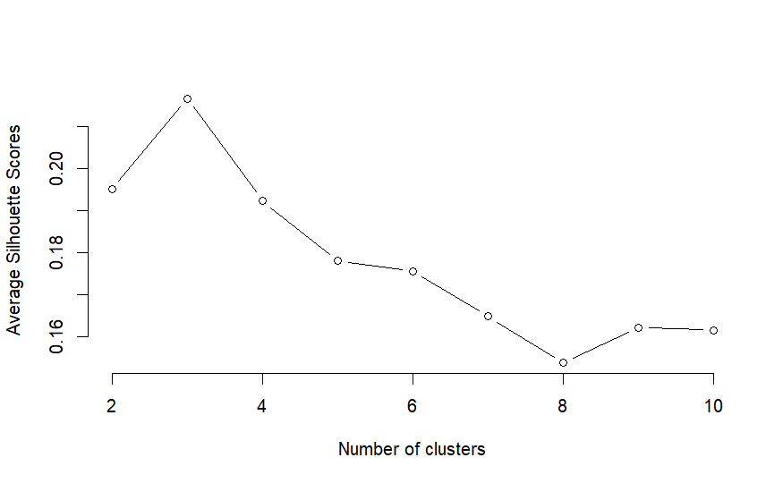

```r
silhouette_score <- function(k) {
  km <- kmeans(Hobby_Data2, centers = k, nstart = 25)
  ss <- silhouette(km$cluster, dist(Hobby_Data2))
  sil <- mean(ss[, 3])
  return(sil)
}

# k cluster range from 2 to 10
k <- 2:10

# call function for each k value
avg_sil <- sapply(k, silhouette_score)

# plot the results
plot(k, avg_sil, type = 'b', xlab = 'Number of clusters', ylab = 'Average Silhouette Scores', frame = FALSE)
```

**k-means cluster k=3**

```r
#set a seed for random number generation  to make the results reproducible
set.seed(7)
kmeans.result <- kmeans(Hobby_Data2, 3)

# print the clusterng result
kmeans.result
```

```
K-means clustering with 3 clusters of sizes 898, 455, 248

Cluster means:
  Olympiad_Participation Scholarship     Fav_sub   Projects  Grasp_pow  Time_sprt Career_sprt   Act_sprt   Fant_arts    Won_arts
1             -0.5792248  -0.5704565  0.10029966 -0.2082862 -0.1861974  0.2435115   0.4875308  0.4083680  0.09278655  0.05802251
2              0.8457102   0.8784672 -0.16713553  0.2128220  0.2782403 -0.3593304  -0.6562209 -0.5007245 -0.23923040 -0.85361446
3              0.5457489   0.4539008 -0.05654206  0.3637377  0.1637335 -0.2224920  -0.5613798 -0.5600193  0.10293351  1.35600952
    Time_art Predicted Hobby
1  0.3171957       0.7272791
2 -0.3880720      -1.0130006
3 -0.4365685      -0.7749248

Clustering vector:
   [1] 3 2 2 3 2 2 2 3 2 2 2 2 3 3 2 2 2 2 2 2 2 2 2 2 2 3 2 2 2 2 2 3 2 2 2 2 3 3 3 3 2 2 2 3 3 3 3 3 3 2 3 3 3 3 3 2 3 3 2 3 2 3 2 2 2
  [66] 3 3 2 2 2 2 2 3 2 2 2 3 2 2 3 3 2 2 3 2 2 2 3 3 2 3 3 3 3 2 2 3 3 2 3 3 3 3 3 2 2 2 2 3 2 2 3 3 3 3 3 2 2 2 3 2 2 3 2 3 3 2 2 2 2
 [131] 3 3 2 3 3 3 2 2 2 3 3 3 2 3 2 2 3 3 2 3 3 2 2 2 2 3 2 3 2 2 2 3 3 2 3 3 3 2 2 2 2 2 2 2 2 3 2 2 3 2 2 2 2 2 2 3 2 2 3 2 2 3 2 3 2
 [196] 2 2 2 2 2 2 2 2 2 2 2 2 2 2 2 2 2 2 2 2 2 2 2 2 2 2 2 2 3 2 2 2 2 2 2 2 2 2 2 2 2 2 2 2 2 2 2 2 2 2 2 2 2 2 2 2 2 3 2 2 2 2 2 3 3
 [261] 2 2 2 2 2 2 2 2 2 2 2 2 2 2 2 2 2 2 2 2 2 2 2 2 2 2 2 2 2 2 2 2 2 2 2 2 2 2 2 2 2 2 2 2 2 2 2 2 2 2 2 2 2 2 2 2 2 2 2 2 2 2 2 2 3
 [326] 2 2 2 2 2 2 3 2 2 2 2 2 2 3 2 2 3 2 2 2 3 2 2 2 2 2 3 3 2 2 2 2 2 2 2 3 2 3 2 2 2 2 2 2 2 3 3 2 2 2 2 2 2 2 2 2 2 2 2 2 2 2 2 2 2
 [391] 2 3 2 2 2 2 2 2 3 2 2 2 2 2 2 2 3 2 3 2 2 2 2 2 2 2 3 3 3 2 3 2 2 2 3 3 2 2 2 2 2 2 2 2 2 2 3 2 2 3 2 2 2 2 2 2 3 2 3 3 2 2 3 2 1
 [456] 2 3 2 3 3 2 2 2 3 3 3 2 3 2 3 3 2 2 2 2 2 2 3 2 3 2 3 2 2 3 2 2 3 3 2 3 3 3 2 1 2 2 3 3 2 2 3 2 2 2 2 2 3 3 2 3 2 3 2 2 2 3 3 3 2
 [521] 1 2 3 3 2 2 2 3 1 2 2 1 3 2 2 3 2 3 3 1 1 1 2 3 2 3 3 2 1 1 3 1 2 2 2 1 1 2 2 3 1 3 2 1 1 2 2 2 2 1 3 2 1 3 2 3 1 3 2 1 1 2 2 1 2
 [586] 2 2 3 1 2 2 3 2 3 2 2 2 3 1 2 3 1 1 3 3 2 3 2 3 3 2 2 2 3 2 2 1 2 3 2 3 3 3 2 2 3 1 1 2 3 2 3 3 2 2 3 2 3 2 1 2 2 3 1 2 3 3 3 2 3
 [651] 2 2 3 3 1 3 1 2 1 3 3 3 2 2 2 3 1 1 2 2 1 1 2 2 2 1 1 3 3 2 2 3 3 3 1 3 1 3 2 3 3 3 1 3 2 1 2 2 2 1 1 1 1 1 1 1 1 1 1 1 3 1 1 1 1
 [716] 1 1 1 1 1 1 1 1 1 1 1 1 1 1 1 1 1 1 1 1 1 1 1 1 1 1 1 1 1 1 1 1 1 1 1 1 1 1 1 1 1 1 1 1 1 1 1 1 1 1 1 1 1 1 1 1 1 1 1 1 3 1 1 1 1
 [781] 1 1 1 1 1 1 1 1 1 1 1 1 1 1 1 1 1 1 1 1 1 1 1 1 1 1 1 1 1 1 1 1 1 1 1 1 1 1 1 1 1 1 1 1 1 1 1 1 1 1 1 1 1 1 1 1 1 1 1 1 1 1 1 1 1
 [846] 1 1 1 1 1 1 1 1 1 1 1 1 1 1 1 3 1 1 3 1 1 1 1 3 1 1 1 1 1 1 1 1 3 1 1 1 1 1 1 1 1 1 1 1 1 1 1 1 1 1 1 1 1 1 1 1 1 1 1 3 1 3 1 1 1
 [911] 1 3 3 1 1 1 1 1 1 1 1 1 1 1 1 1 1 3 1 1 3 1 3 1 1 1 1 1 1 1 1 1 1 1 1 1 2 1 3 1 1 1 1 1 1 1 1 1 1 1 1 1 1 3 1 1 1 1 1 1 3 1 1 1 1
 [976] 1 1 1 3 1 1 1 1 1 1 1 1 3 3 1 1 1 1 1 3 1 1 1 3 1
 [ reached getOption("max.print") -- omitted 601 entries ]

Within cluster sum of squares by cluster:
[1] 9294.603 3090.057 2155.046
 (between_SS / total_SS =  24.3 %)

Available components:

[1] "cluster"      "centers"      "totss"        "withinss"     "tot.withinss" "betweenss"    "size"         "iter"
[9] "ifault"
```

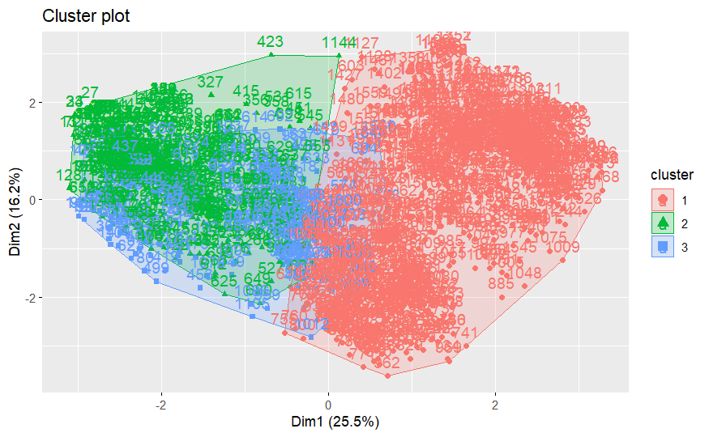

```r
#visualize clustering
fviz_cluster(kmeans.result, data = Hobby_Data2)
```

**Average for each cluster**

|  | cluster | size | ave.sil.width |
| --- | --- | --- | --- |
| 1 | 1 | 898 | 0.13 |
| 2 | 2 | 455 | 0.21 |
| 3 | 3 | 248 | 0.09 |

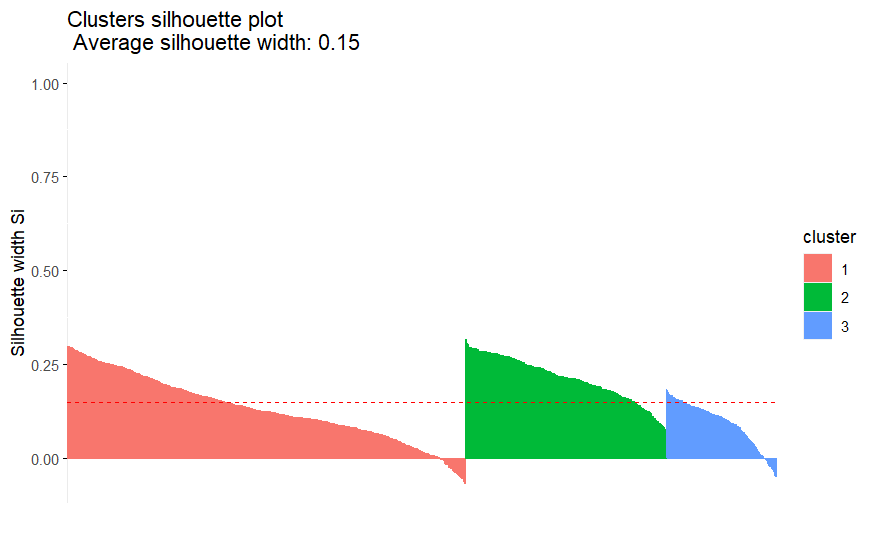

```r
avg_sil <- silhouette(kmeans.result$cluster,dist(Hobby_Data2))
fviz_silhouette(avg_sil)
```

So since 3, which was the optimal number of clusters with the highest silhouette score average, did not have good clustering results, that does support our research results that the k-means algorithm is not applicable to categoricaldata clustering because it relies on the Euclidean distance metric tomeasure the similarity between data points. However, even afterEncoding and its application to categorical data pose significant challenges. Categorical variables often lack a meaningful numericalrepresentation; for instance, taking the mean of categories like thefeature “favorite subject,” aka Fav_sub” (even after encoding), might nothave any practical interpretation. And the distances calculated in thealgorithm may not reflect the true dissimilarities between categoricalvalues. The encoding process itself introduces artificial numericalrelationships that may mislead the algorithm. Moreover, k-means relieson the minimization of Euclidean distances, which might not accuratelycapture the dissimilarity structure in categorical data. Categoricalvariables inherently exhibit discrete and non-ordinal characteristicsthat are not well-suited for the continuous and linear assumptions ofk-means. Alternative clustering techniques, specifically designed forcategorical data, such as partitioning around medoids, are moreappropriate for capturing the intrinsic patterns and relationships incategorical datasets.[7]

**k-mediods clustering with PAM**

K-medoids clustering presents a robust alternative for analyzing categorical data by addressing the limitations posed by k-means clustering. Unlike k-means, k-medoids does not rely on the mean as a representative centroid but employs medoids, which are actual data points within the clusters, and the algorithm defines clusters based on partitioning around medoids. This feature makes k-medoids particularly suitable for categorical data, where meaningful centroids may not have a numerical interpretation. The algorithm defines clusters based on partitioning around medoids.

**Validation:**

First, we want to determine three different numbers of clusters by using a number of methods that will suggest the optimal number of clusters for k-mediods clustering with PAM.[8]

**Silhouette coefficient**

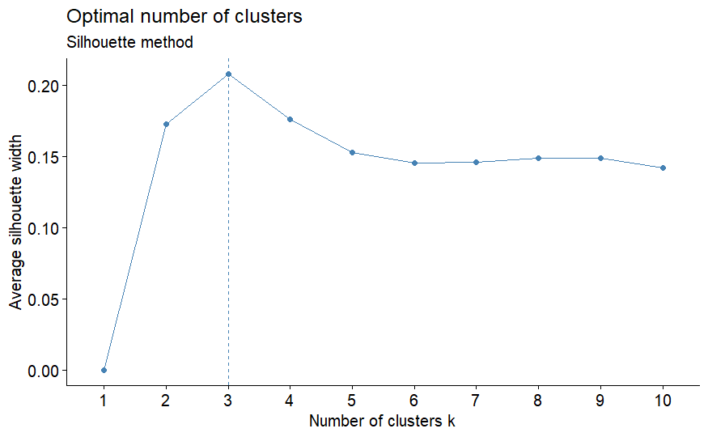

```r
fviz_nbclust(Hobby_Data2, pam, method = "silhouette")+
  labs(subtitle = "Silhouette method")
```

**Elbow method**

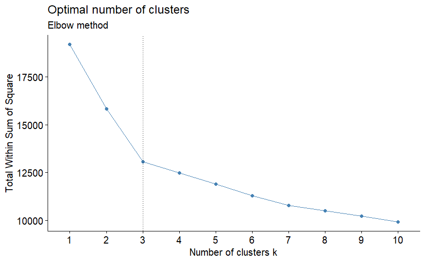

```r
fviz_nbclust(Hobby_Data2, pam, method = "wss") +
  geom_vline(xintercept= 3, linetype= 3)+
  labs(subtitle = "Elbow method")
```

The silhouette coefficient, which measures the cohesion and separation of clusters, aligns with the Elbow method, which assesses the within-cluster sum of squares (wss) as a function of the number of clusters in the suggested optimal number of clusters. This alignment in results between two distinct evaluation methods strengthens confidence in the choice of three clusters, providing a stable foundation for further analysis and interpretation of the underlying patterns within the dataset. In addition to that, the ground truth (class labels) also contains three classes, and that indicates a reassuring alignment between the structure of the data and the clustering results.

We need to determine two more suggested numbers of clusters by computing the average silhouette for k clusters using silhouette().

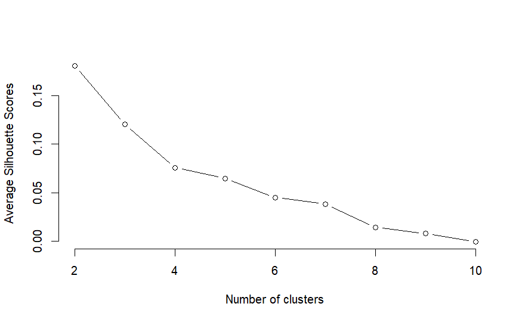

```r
silhouette_score <- function(k) {
  km <- pam(Hobby_Data2, k, diss = TRUE)
  ss <- silhouette(km$clustering, dist(Hobby_Data2))
  sil <- mean(ss[, 3])
  return(sil)
}

# k cluster range from 2 to 10
k <- 2:10

# Call function for each k value
avg_sil <- sapply(k, silhouette_score)
# Plot the results
plot(k, avg_sil, type = 'b', xlab = 'Number of clusters', ylab = 'Average Silhouette Scores', frame = FALSE)
```

It is a common practice to choose the number of clusters corresponding to the peak in the silhouette score plot, and since we are looking for two more number of clusters other than three, it would be reasonable to consider two and four clusters for further analysis. Especially with the decreasing trend beyond three clusters, it indicates that adding more clusters does not significantly improve the separation and cohesion of the clusters.

**group into k=3 clusters**

The sub-sampling and clustering approach is a helpful method to evaluate the robustness of the clustering results under various subsets and to obtain insights into the structure of the data. Furthermore, we will take 100 samples from our data set to ensure that the clustering plot doesn’t get too crowded.

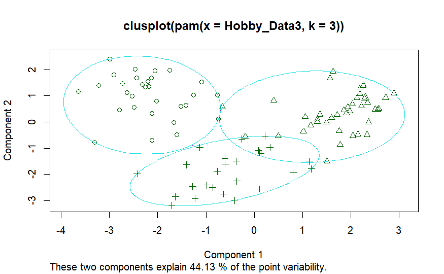

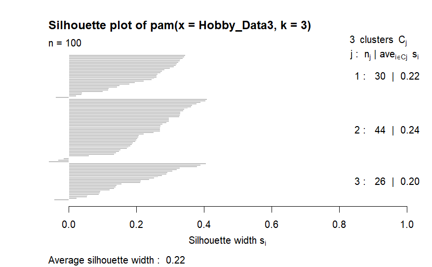

```r
set.seed(7)

# Specify the number of rows you want to sample
num_rows <- 100

# Use sample with the specified seed
idx <- sample(1:dim(Hobby_Data2)[1], num_rows)

Hobby_Data3 <- Hobby_Data2[idx, ]

pam.result <- pam(Hobby_Data3,3)
#Show the silhoutee plot of PAM AND clusters
plot(pam.result)
```

The output of the code, displaying a silhouette plot of the PAM clusters, indicates that the clusters are relatively close to each other, with a slight overlap between two clusters. The silhouette plot visually represents how well-defined and separated the clusters are. While the slight overlap suggests that the natural grouping within the dataset may not be entirely distinct, it does not negatively affect the overall quality of the clusters. In fact, the observed overlap might indicate shared characteristics between adjacent clusters, effectively capturing meaningful patterns and groupings that reflect the intricacies of real-world phenomena not confined to strict boundaries.

wws

```r
# Extract the clusinfo component
clusinfo <- pam.result$clusinfo

# Calculate the total within-cluster sum of squares
tot_withinss <- sum(clusinfo[, "size"] * clusinfo[, "av_diss"]^2)

# Print the result
print(tot_withinss)
```

```
[1] 833.5585
```

bCubed

```r
cluster_assignments <- c(pam.result$cluster)
set.seed(7)

# Specify the number of rows you want to sample
num_rows <- 100

# Use sample with the specified seed
idx <- sample(1:dim(Hobby_proc)[1], num_rows)

# Select the sampled rows from Hobby_proc
Hobby_Data4 <- Hobby_proc[idx, ]
ground_truth_labels <- c(Hobby_Data4)

# Create a data frame with cluster assignments and ground truth labels
dataset <- data.frame(cluster = cluster_assignments, label = ground_truth_labels)

# Calculate BCubed precision and recall
calculate_bcubed_metrics <- function(dataset) {
  n <- nrow(dataset)
  precision_sum <- 0
  recall_sum <- 0

   for (i in 1:n) {
    cluster <- dataset$cluster[i]
    label <- dataset$label[i]

    # Count the number of items from the same category in its cluster
    same_category <- sum(dataset$label[dataset$cluster == cluster] == label)

    # Count the number of items in its cluster
    same_cluster <- sum(dataset$cluster == cluster)

    # Count the number of items in its category
    total_same_category <- sum(dataset$label == label)

    # Calculate precision and recall
    precision_sum <- precision_sum + same_category / same_cluster
    recall_sum <- recall_sum + same_category / total_same_category
    }
  # End loop

  # Calculate average precision and recall
  precision <- precision_sum / n
  recall <- recall_sum / n
  return(list(precision = precision, recall = recall))}

  # Calculate BCubed precision and recall
  metrics <- calculate_bcubed_metrics(dataset)
  precision <- metrics$precision
  recall <- metrics$recall

# Print the results
  cat("BCubed Precision= ", precision, "AND BCubed Recall= ", recall, "\n")
```

```
BCubed Precision=  0.0487803 AND BCubed Recall=  0.4932381
```

While precision highlights room for better accuracy in identifying similar items, the higher recall indicates the algorithm’s capability to catch a good amount of actual similarities within clusters.

**group into k=4 clusters**

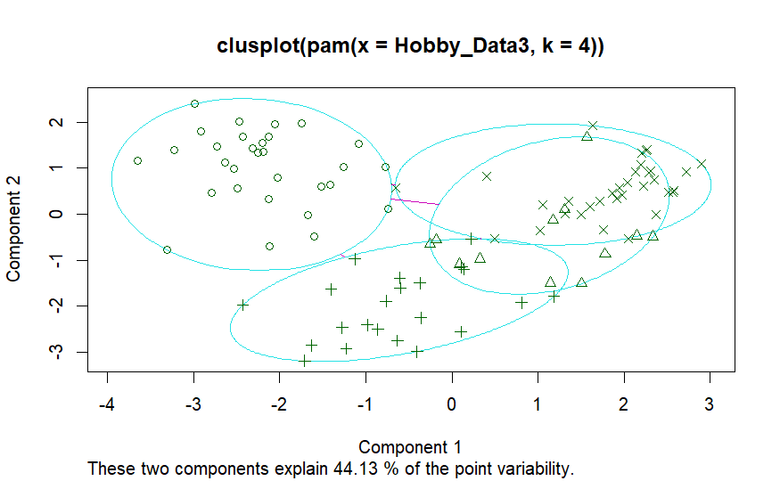

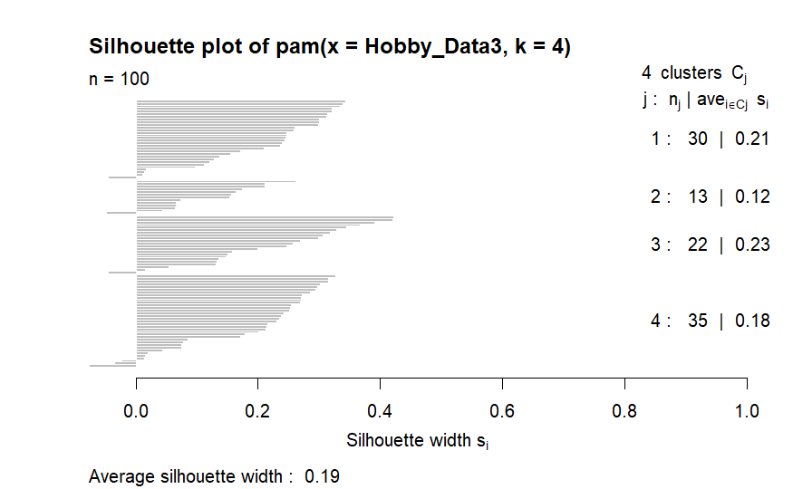

```r
set.seed(7)

# Specify the number of rows you want to sample
num_rows <- 100

# Use sample with the specified seed
idx <- sample(1:dim(Hobby_Data2)[1], num_rows)

Hobby_Data3 <- Hobby_Data2[idx, ]

pam.result <- pam(Hobby_Data3,4)
#Show the silhoutee plot of PAM AND clusters
plot(pam.result)
```

wws

```r
# Extract the clusinfo component
clusinfo <- pam.result$clusinfo

# Calculate the total within-cluster sum of squares
tot_withinss <- sum(clusinfo[, "size"] * clusinfo[, "av_diss"]^2)

# Print the result
print(tot_withinss)
```

```
[1] 762.8895
```

The output suggests that the dataset may exhibit a degree of overlap or similarity among observations. The overlapping clusters may indicate challenges in achieving a clear separation among these groups. The placement of one cluster on top of two others implies that the medoid of this cluster might be near points belonging to those two neighboring clusters. This could be due to the nature of the data.